```python
!pip install catboost
```

```
     ━━━━━━━━━━━━━━━━━━━━━━━━━━━━━━━━━━━━━━━━ 98.7/98.7 MB 7.3 MB/s eta 0:00:00
```

```python
import pandas as pd
import matplotlib.pyplot as plt
import seaborn as sns
from scipy.stats import kruskal
from imblearn.combine import SMOTETomek
from collections import Counter
from catboost import CatBoostClassifier
from sklearn.metrics import roc_auc_score,accuracy_score, classification_report,f1_score
from sklearn.model_selection import GridSearchCV,train_test_split
import xgboost as xgb
```

```python
data1=pd.read_csv('/content/drive/MyDrive/Nationwide/TRAIN_SET_2023.csv')
data1
```

|  | RESTAURANT_SERIAL_NUMBER | RESTAURANT_PERMIT_NUMBER | RESTAURANT_NAME | RESTAURANT_LOCATION | RESTAURANT_CATEGORY | ADDRESS | CITY | STATE | ZIP | CURRENT_DEMERITS | ... | LAT_LONG_RAW | FIRST_VIOLATION | SECOND_VIOLATION | THIRD_VIOLATION | FIRST_VIOLATION_TYPE | SECOND_VIOLATION_TYPE | THIRD_VIOLATION_TYPE | NUMBER_OF_VIOLATIONS | NEXT_INSPECTION_GRADE_C_OR_BELOW | INPSECTION_FORMAT |
| --- | --- | --- | --- | --- | --- | --- | --- | --- | --- | --- | --- | --- | --- | --- | --- | --- | --- | --- | --- | --- | --- |
| 0 | DA1117270 | PR0004527 | SANDS EXPO HALL B2 CONCESSION | SANDS EXPO & CONVENTION CENTER | Food Truck | 201 E Sands Ave | Las Vegas | Nevada | 89169-2617 | 0.0 | ... | (36.1221442, 115.1652749) | 204.0 | 215.0 | 302.0 | Critical | Major | Imminent Health Hazard | 4 | 0.0 | Virtual |
| 1 | DA1014948 | PR0024221 | THAI NOODLES CAFE - RESTAURANT | THAI NOODLES CAFE | Restaurant | 6710 W CHEYENNE Ave | Las Vegas | Nevada | 89108-4588 | 3.0 | ... | (36.218691, 115.242913) | 214.0 | 216.0 | 229.0 | Major | Major | Non-Major | 5 | 0.0 | Virtual |
| 2 | DA0861994 | PR0019017 | SANTA FE SPORTS BOOK GRILL | Santa Fe Station Hotel & Casino | Restaurant | 4949 N Rancho Dr | Las Vegas | Nevada | 89130-3505 | 8.0 | ... | (36.2498922, 115.2441383) | 202.0 | 215.0 | 233.0 | Critical | Major | Non-Major | 3 | 1.0 | Virtual |
| 3 | DA0896719 | PR0001343 | Bracken, Walter Elem School Kit | Bracken, Walter Elem School | Elementary School Kitchen | 1200 N 27Th St | Las Vegas | Nevada | 89101-1517 | 0.0 | ... | (36.183669, 115.112355) | 214.0 | 230.0 | 233.0 | Major | Non-Major | Non-Major | 3 | 0.0 | Virtual |
| 4 | DA1031041 | PR0006084 | HARD ROCK JOINT EAST SVC BAR FL 1 | HARD ROCK HOTEL & CASINO | Bar / Tavern | 4455 S Paradise Rd | Las Vegas | Nevada | 89169-6574 | 0.0 | ... | (36.1100828, 115.1538714) | 214.0 | 230.0 | 233.0 | Major | Non-Major | Non-Major | NaN | 0.0 | Virtual |
| ... | ... | ... | ... | ... | ... | ... | ... | ... | ... | ... | ... | ... | ... | ... | ... | ... | ... | ... | ... | ... | ... |
| 17190 | DA0371445 | PR0008648 | Krispy Kreme Doughnuts #940 | L & L Enterprise Holdings, LLC | Restaurant | 7015 W Spring Mountain Rd | Las Vegas | Nevada | 89117-3818 | 9.0 | ... | (36.125571, 115.2457) | 18.0 | 28.0 | 36.0 | Non-Major | Non-Major | Non-Major | 4 | 0.0 | NaN |
| 17191 | DA0371445 | PR0008648 | Krispy Kreme Doughnuts #940 | L & L Enterprise Holdings, LLC | Restaurant | 7015 W Spring Mountain Rd | Las Vegas | Nevada | 89117-3818 | 9.0 | ... | (36.125571, 115.2457) | 18.0 | 28.0 | 36.0 | Non-Major | Non-Major | Non-Major | 4 | 0.0 | NaN |
| 17192 | DA0371445 | PR0008648 | Krispy Kreme Doughnuts #940 | L & L Enterprise Holdings, LLC | Restaurant | 7015 W Spring Mountain Rd | Las Vegas | Nevada | 89117-3818 | 9.0 | ... | (36.125571, 115.2457) | 18.0 | 28.0 | 36.0 | Non-Major | Non-Major | Non-Major | 4 | 0.0 | NaN |
| 17193 | DA0371445 | PR0008648 | Krispy Kreme Doughnuts #940 | L & L Enterprise Holdings, LLC | Restaurant | 7015 W Spring Mountain Rd | Las Vegas | Nevada | 89117-3818 | 9.0 | ... | (36.125571, 115.2457) | 18.0 | 28.0 | 36.0 | Non-Major | Non-Major | Non-Major | 4 | 0.0 | NaN |
| 17194 | DA0371445 | PR0008648 | Krispy Kreme Doughnuts #940 | L & L Enterprise Holdings, LLC | Restaurant | 7015 W Spring Mountain Rd | Las Vegas | Nevada | 89117-3818 | 9.0 | ... | (36.125571, 115.2457) | 18.0 | 28.0 | 36.0 | Non-Major | Non-Major | Non-Major | 4 | 0.0 | NaN |

17195 rows × 29 columns

```python
data1.dtypes
```

```
RESTAURANT_SERIAL_NUMBER             object
RESTAURANT_PERMIT_NUMBER             object
RESTAURANT_NAME                      object
RESTAURANT_LOCATION                  object
RESTAURANT_CATEGORY                  object
ADDRESS                              object
CITY                                 object
STATE                                object
ZIP                                  object
CURRENT_DEMERITS                    float64
CURRENT_GRADE                        object
EMPLOYEE_COUNT                      float64
MEDIAN_EMPLOYEE_AGE                  object
MEDIAN_EMPLOYEE_TENURE              float64
INSPECTION_TIME                      object
INSPECTION_TYPE                      object
INSPECTION_DEMERITS                  object
VIOLATIONS_RAW                       object
RECORD_UPDATED                       object
LAT_LONG_RAW                         object
FIRST_VIOLATION                     float64
SECOND_VIOLATION                    float64
THIRD_VIOLATION                     float64
FIRST_VIOLATION_TYPE                 object
SECOND_VIOLATION_TYPE                object
THIRD_VIOLATION_TYPE                 object
NUMBER_OF_VIOLATIONS                 object
NEXT_INSPECTION_GRADE_C_OR_BELOW    float64
INPSECTION_FORMAT                    object
dtype: object
```

```python
data1.columns
```

```
Index(['RESTAURANT_SERIAL_NUMBER', 'RESTAURANT_PERMIT_NUMBER',
       'RESTAURANT_NAME', 'RESTAURANT_LOCATION', 'RESTAURANT_CATEGORY',
       'ADDRESS', 'CITY', 'STATE', 'ZIP', 'CURRENT_DEMERITS', 'CURRENT_GRADE',
       'EMPLOYEE_COUNT', 'MEDIAN_EMPLOYEE_AGE', 'MEDIAN_EMPLOYEE_TENURE',
       'INSPECTION_TIME', 'INSPECTION_TYPE', 'INSPECTION_DEMERITS',
       'VIOLATIONS_RAW', 'RECORD_UPDATED', 'LAT_LONG_RAW', 'FIRST_VIOLATION',
       'SECOND_VIOLATION', 'THIRD_VIOLATION', 'FIRST_VIOLATION_TYPE',
       'SECOND_VIOLATION_TYPE', 'THIRD_VIOLATION_TYPE', 'NUMBER_OF_VIOLATIONS',
       'NEXT_INSPECTION_GRADE_C_OR_BELOW', 'INPSECTION_FORMAT'],
      dtype='object')
```

```python
cols=['RESTAURANT_SERIAL_NUMBER', 'RESTAURANT_PERMIT_NUMBER',
       'RESTAURANT_NAME', 'RESTAURANT_LOCATION','ZIP']
```

```python
data1=data1.drop(columns=cols,axis=1).copy()
data1
```

|  | RESTAURANT_CATEGORY | ADDRESS | CITY | STATE | CURRENT_DEMERITS | CURRENT_GRADE | EMPLOYEE_COUNT | MEDIAN_EMPLOYEE_AGE | MEDIAN_EMPLOYEE_TENURE | INSPECTION_TIME | ... | LAT_LONG_RAW | FIRST_VIOLATION | SECOND_VIOLATION | THIRD_VIOLATION | FIRST_VIOLATION_TYPE | SECOND_VIOLATION_TYPE | THIRD_VIOLATION_TYPE | NUMBER_OF_VIOLATIONS | NEXT_INSPECTION_GRADE_C_OR_BELOW | INPSECTION_FORMAT |
| --- | --- | --- | --- | --- | --- | --- | --- | --- | --- | --- | --- | --- | --- | --- | --- | --- | --- | --- | --- | --- | --- |
| 0 | Food Truck | 201 E Sands Ave | Las Vegas | Nevada | 0.0 | C | 25.0 | 27.95998269 | 13.004886 | 11/5/2013 16:15 | ... | (36.1221442, 115.1652749) | 204.0 | 215.0 | 302.0 | Critical | Major | Imminent Health Hazard | 4 | 0.0 | Virtual |
| 1 | Restaurant | 6710 W CHEYENNE Ave | Las Vegas | Nevada | 3.0 | A | 7.0 | 27.71936533 | 3.922086 | 9/21/2012 13:00 | ... | (36.218691, 115.242913) | 214.0 | 216.0 | 229.0 | Major | Major | Non-Major | 5 | 0.0 | Virtual |
| 2 | Restaurant | 4949 N Rancho Dr | Las Vegas | Nevada | 8.0 | A | 23.0 | 26.44263674 | 10.312777 | 9/16/2011 11:50 | ... | (36.2498922, 115.2441383) | 202.0 | 215.0 | 233.0 | Critical | Major | Non-Major | 3 | 1.0 | Virtual |
| 3 | Elementary School Kitchen | 1200 N 27Th St | Las Vegas | Nevada | 0.0 | A | 14.0 | 33.98829267 | 4.163975 | 11/22/2011 11:40 | ... | (36.183669, 115.112355) | 214.0 | 230.0 | 233.0 | Major | Non-Major | Non-Major | 3 | 0.0 | Virtual |
| 4 | Bar / Tavern | 4455 S Paradise Rd | Las Vegas | Nevada | 0.0 | A | 10.0 | 21.98028217 | 13.462786 | 11/9/2012 20:30 | ... | (36.1100828, 115.1538714) | 214.0 | 230.0 | 233.0 | Major | Non-Major | Non-Major | NaN | 0.0 | Virtual |
| ... | ... | ... | ... | ... | ... | ... | ... | ... | ... | ... | ... | ... | ... | ... | ... | ... | ... | ... | ... | ... | ... |
| 17190 | Restaurant | 7015 W Spring Mountain Rd | Las Vegas | Nevada | 9.0 | A | 9.0 | 33.38377274 | 4.830165 | 5/14/2010 10:20 | ... | (36.125571, 115.2457) | 18.0 | 28.0 | 36.0 | Non-Major | Non-Major | Non-Major | 4 | 0.0 | NaN |
| 17191 | Restaurant | 7015 W Spring Mountain Rd | Las Vegas | Nevada | 9.0 | A | 9.0 | 33.38377274 | 4.830165 | 5/14/2010 10:20 | ... | (36.125571, 115.2457) | 18.0 | 28.0 | 36.0 | Non-Major | Non-Major | Non-Major | 4 | 0.0 | NaN |
| 17192 | Restaurant | 7015 W Spring Mountain Rd | Las Vegas | Nevada | 9.0 | A | 9.0 | 33.38377274 | 4.830165 | 5/14/2010 10:20 | ... | (36.125571, 115.2457) | 18.0 | 28.0 | 36.0 | Non-Major | Non-Major | Non-Major | 4 | 0.0 | NaN |
| 17193 | Restaurant | 7015 W Spring Mountain Rd | Las Vegas | Nevada | 9.0 | A | 9.0 | 33.38377274 | 4.830165 | 5/14/2010 10:20 | ... | (36.125571, 115.2457) | 18.0 | 28.0 | 36.0 | Non-Major | Non-Major | Non-Major | 4 | 0.0 | NaN |
| 17194 | Restaurant | 7015 W Spring Mountain Rd | Las Vegas | Nevada | 9.0 | A | 9.0 | 33.38377274 | 4.830165 | 5/14/2010 10:20 | ... | (36.125571, 115.2457) | 18.0 | 28.0 | 36.0 | Non-Major | Non-Major | Non-Major | 4 | 0.0 | NaN |

17195 rows × 24 columns

```python
(data1.isnull().sum()/17195 )*100.0
```

```
RESTAURANT_CATEGORY                  0.756034
ADDRESS                              0.407095
CITY                                 1.372492
STATE                                1.215470
CURRENT_DEMERITS                     1.256179
CURRENT_GRADE                        1.634196
EMPLOYEE_COUNT                       0.540855
MEDIAN_EMPLOYEE_AGE                  0.197732
MEDIAN_EMPLOYEE_TENURE               1.727246
INSPECTION_TIME                      1.064263
INSPECTION_TYPE                      1.285257
INSPECTION_DEMERITS                  1.477174
VIOLATIONS_RAW                       0.959581
RECORD_UPDATED                       0.692062
LAT_LONG_RAW                         0.087235
FIRST_VIOLATION                      1.232917
SECOND_VIOLATION                     0.494330
THIRD_VIOLATION                      0.354754
FIRST_VIOLATION_TYPE                 0.849084
SECOND_VIOLATION_TYPE                1.552777
THIRD_VIOLATION_TYPE                 1.006106
NUMBER_OF_VIOLATIONS                 0.982844
NEXT_INSPECTION_GRADE_C_OR_BELOW     0.220994
INPSECTION_FORMAT                   61.744693
dtype: float64
```

```python
data1.isnull().sum()
```

```
RESTAURANT_CATEGORY                   130
ADDRESS                                70
CITY                                  236
STATE                                 209
CURRENT_DEMERITS                      216
CURRENT_GRADE                         281
EMPLOYEE_COUNT                         93
MEDIAN_EMPLOYEE_AGE                    34
MEDIAN_EMPLOYEE_TENURE                297
INSPECTION_TIME                       183
INSPECTION_TYPE                       221
INSPECTION_DEMERITS                   254
VIOLATIONS_RAW                        165
RECORD_UPDATED                        119
LAT_LONG_RAW                           15
FIRST_VIOLATION                       212
SECOND_VIOLATION                       85
THIRD_VIOLATION                        61
FIRST_VIOLATION_TYPE                  146
SECOND_VIOLATION_TYPE                 267
THIRD_VIOLATION_TYPE                  173
NUMBER_OF_VIOLATIONS                  169
NEXT_INSPECTION_GRADE_C_OR_BELOW       38
INPSECTION_FORMAT                   10617
dtype: int64
```

```python
null_percentages = (data1.isna().mean() * 100).round(2)
null_percentages = null_percentages[null_percentages > 0]
null_percentages = null_percentages.sort_values(ascending=False)
```

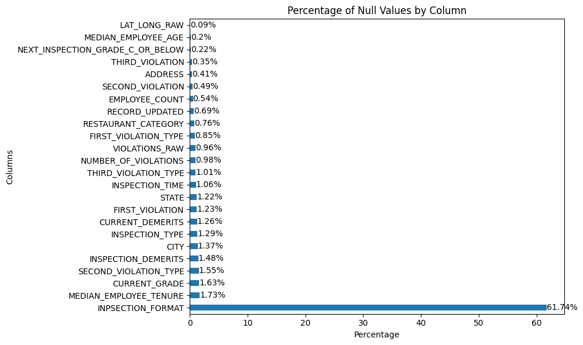

```python
plt.figure(figsize=(10, 6))
ax=null_percentages.plot(kind='barh')
plt.title('Percentage of Null Values by Column')
plt.xlabel('Percentage')
plt.ylabel('Columns')

for i, v in enumerate(null_percentages):
    plt.text(v, i, f'{v}%', va='center', fontsize=10)
plt.tight_layout()
plt.show()
```

Before applyting any sort of preprocessing on data, just want to conduct Hypothesis to understand the impact of feature on target vairable. Because if I apply pd.dropna(), I lose 20% of data.

I ran a two-sided Kruskal Wallis test. Given our group standard deviations were not equal, I decided it was not appropriate to use an ANOVA.

*Does* INSPECTION_TYPE effects the NEXT_INSPECTION_GRADE_C_OR_BELOW ?

```python
group_Routine_Inspection = data1[data1['INSPECTION_TYPE'] == 'Routine Inspection']['NEXT_INSPECTION_GRADE_C_OR_BELOW'].dropna()
group_Re_inspection = data1[data1['INSPECTION_TYPE'] == 'Re-inspection']['NEXT_INSPECTION_GRADE_C_OR_BELOW'].dropna()
group_Typical_Inspection = data1[data1['INSPECTION_TYPE'] == 'Typical Inspection']['NEXT_INSPECTION_GRADE_C_OR_BELOW'].dropna()

statistic, p_value = kruskal(group_Routine_Inspection,group_Re_inspection,group_Typical_Inspection)

print("p-value:", p_value)

alpha = 0.05
if p_value < alpha:
    print("Reject the null hypothesis: 'INSPECTION_TYPE' has a significant effect on 'NEXT_INSPECTION_GRADE_C_OR_BELOW.'")
else:
    print("Fail to reject the null hypothesis: 'INSPECTION_TYPE' does not have a significant effect on 'NEXT_INSPECTION_GRADE_C_OR_BELOW.'")
```

```
p-value: 0.08881829593892146
Fail to reject the null hypothesis: 'INSPECTION_TYPE' does not have a significant effect on 'NEXT_INSPECTION_GRADE_C_OR_BELOW.'
```

% of missing data dropped from 20 to 13

by removing below irrelevant columns

```python
data2=data1.drop(columns=['INPSECTION_FORMAT','ADDRESS','CITY','STATE','INSPECTION_TIME','INSPECTION_TYPE','VIOLATIONS_RAW','RECORD_UPDATED','LAT_LONG_RAW'],axis=1).copy()
data2
```

|  | RESTAURANT_CATEGORY | CURRENT_DEMERITS | CURRENT_GRADE | EMPLOYEE_COUNT | MEDIAN_EMPLOYEE_AGE | MEDIAN_EMPLOYEE_TENURE | INSPECTION_DEMERITS | FIRST_VIOLATION | SECOND_VIOLATION | THIRD_VIOLATION | FIRST_VIOLATION_TYPE | SECOND_VIOLATION_TYPE | THIRD_VIOLATION_TYPE | NUMBER_OF_VIOLATIONS | NEXT_INSPECTION_GRADE_C_OR_BELOW |
| --- | --- | --- | --- | --- | --- | --- | --- | --- | --- | --- | --- | --- | --- | --- | --- |
| 0 | Food Truck | 0.0 | C | 25.0 | 27.95998269 | 13.004886 | 11 | 204.0 | 215.0 | 302.0 | Critical | Major | Imminent Health Hazard | 4 | 0.0 |
| 1 | Restaurant | 3.0 | A | 7.0 | 27.71936533 | 3.922086 | 9 | 214.0 | 216.0 | 229.0 | Major | Major | Non-Major | 5 | 0.0 |
| 2 | Restaurant | 8.0 | A | 23.0 | 26.44263674 | 10.312777 | 9 | 202.0 | 215.0 | 233.0 | Critical | Major | Non-Major | 3 | 1.0 |
| 3 | Elementary School Kitchen | 0.0 | A | 14.0 | 33.98829267 | 4.163975 | 5 | 214.0 | 230.0 | 233.0 | Major | Non-Major | Non-Major | 3 | 0.0 |
| 4 | Bar / Tavern | 0.0 | A | 10.0 | 21.98028217 | 13.462786 | 5 | 214.0 | 230.0 | 233.0 | Major | Non-Major | Non-Major | NaN | 0.0 |
| ... | ... | ... | ... | ... | ... | ... | ... | ... | ... | ... | ... | ... | ... | ... | ... |
| 17190 | Restaurant | 9.0 | A | 9.0 | 33.38377274 | 4.830165 | 4 | 18.0 | 28.0 | 36.0 | Non-Major | Non-Major | Non-Major | 4 | 0.0 |
| 17191 | Restaurant | 9.0 | A | 9.0 | 33.38377274 | 4.830165 | 4 | 18.0 | 28.0 | 36.0 | Non-Major | Non-Major | Non-Major | 4 | 0.0 |
| 17192 | Restaurant | 9.0 | A | 9.0 | 33.38377274 | 4.830165 | 4 | 18.0 | 28.0 | 36.0 | Non-Major | Non-Major | Non-Major | 4 | 0.0 |
| 17193 | Restaurant | 9.0 | A | 9.0 | 33.38377274 | 4.830165 | 4 | 18.0 | 28.0 | 36.0 | Non-Major | Non-Major | Non-Major | 4 | 0.0 |
| 17194 | Restaurant | 9.0 | A | 9.0 | 33.38377274 | 4.830165 | 4 | 18.0 | 28.0 | 36.0 | Non-Major | Non-Major | Non-Major | 4 | 0.0 |

17195 rows × 15 columns

```python
data2=data2.dropna().copy()
```

```python
data2
```

|  | RESTAURANT_CATEGORY | CURRENT_DEMERITS | CURRENT_GRADE | EMPLOYEE_COUNT | MEDIAN_EMPLOYEE_AGE | MEDIAN_EMPLOYEE_TENURE | INSPECTION_DEMERITS | FIRST_VIOLATION | SECOND_VIOLATION | THIRD_VIOLATION | FIRST_VIOLATION_TYPE | SECOND_VIOLATION_TYPE | THIRD_VIOLATION_TYPE | NUMBER_OF_VIOLATIONS | NEXT_INSPECTION_GRADE_C_OR_BELOW |
| --- | --- | --- | --- | --- | --- | --- | --- | --- | --- | --- | --- | --- | --- | --- | --- |
| 0 | Food Truck | 0.0 | C | 25.0 | 27.95998269 | 13.004886 | 11 | 204.0 | 215.0 | 302.0 | Critical | Major | Imminent Health Hazard | 4 | 0.0 |
| 1 | Restaurant | 3.0 | A | 7.0 | 27.71936533 | 3.922086 | 9 | 214.0 | 216.0 | 229.0 | Major | Major | Non-Major | 5 | 0.0 |
| 2 | Restaurant | 8.0 | A | 23.0 | 26.44263674 | 10.312777 | 9 | 202.0 | 215.0 | 233.0 | Critical | Major | Non-Major | 3 | 1.0 |
| 3 | Elementary School Kitchen | 0.0 | A | 14.0 | 33.98829267 | 4.163975 | 5 | 214.0 | 230.0 | 233.0 | Major | Non-Major | Non-Major | 3 | 0.0 |
| 5 | Bar / Tavern | 3.0 | A | 43.0 | 25.94720622 | 3.839934 | 17 | 206.0 | 211.0 | 215.0 | Critical | Major | Major | 7 | 0.0 |
| ... | ... | ... | ... | ... | ... | ... | ... | ... | ... | ... | ... | ... | ... | ... | ... |
| 17190 | Restaurant | 9.0 | A | 9.0 | 33.38377274 | 4.830165 | 4 | 18.0 | 28.0 | 36.0 | Non-Major | Non-Major | Non-Major | 4 | 0.0 |
| 17191 | Restaurant | 9.0 | A | 9.0 | 33.38377274 | 4.830165 | 4 | 18.0 | 28.0 | 36.0 | Non-Major | Non-Major | Non-Major | 4 | 0.0 |
| 17192 | Restaurant | 9.0 | A | 9.0 | 33.38377274 | 4.830165 | 4 | 18.0 | 28.0 | 36.0 | Non-Major | Non-Major | Non-Major | 4 | 0.0 |
| 17193 | Restaurant | 9.0 | A | 9.0 | 33.38377274 | 4.830165 | 4 | 18.0 | 28.0 | 36.0 | Non-Major | Non-Major | Non-Major | 4 | 0.0 |
| 17194 | Restaurant | 9.0 | A | 9.0 | 33.38377274 | 4.830165 | 4 | 18.0 | 28.0 | 36.0 | Non-Major | Non-Major | Non-Major | 4 | 0.0 |

14901 rows × 15 columns

```python
data2.groupby(by='NEXT_INSPECTION_GRADE_C_OR_BELOW').count().iloc[::,:1].reset_index()
```

|  | NEXT_INSPECTION_GRADE_C_OR_BELOW | RESTAURANT_CATEGORY |
| --- | --- | --- |
| 0 | -3.0 | 1 |
| 1 | 0.0 | 12602 |
| 2 | 1.0 | 2294 |
| 3 | 3.0 | 1 |
| 4 | 4.0 | 1 |
| 5 | 7.0 | 1 |
| 6 | 9.0 | 1 |

# Cleaning the data

```python
data2=data2[data2['NEXT_INSPECTION_GRADE_C_OR_BELOW']>=0].copy()
data2=data2[data2['NEXT_INSPECTION_GRADE_C_OR_BELOW']<=1].copy()
data2
```

|  | RESTAURANT_CATEGORY | CURRENT_DEMERITS | CURRENT_GRADE | EMPLOYEE_COUNT | MEDIAN_EMPLOYEE_AGE | MEDIAN_EMPLOYEE_TENURE | INSPECTION_DEMERITS | FIRST_VIOLATION | SECOND_VIOLATION | THIRD_VIOLATION | FIRST_VIOLATION_TYPE | SECOND_VIOLATION_TYPE | THIRD_VIOLATION_TYPE | NUMBER_OF_VIOLATIONS | NEXT_INSPECTION_GRADE_C_OR_BELOW |
| --- | --- | --- | --- | --- | --- | --- | --- | --- | --- | --- | --- | --- | --- | --- | --- |
| 0 | Food Truck | 0.0 | C | 25.0 | 27.95998269 | 13.004886 | 11 | 204.0 | 215.0 | 302.0 | Critical | Major | Imminent Health Hazard | 4 | 0.0 |
| 1 | Restaurant | 3.0 | A | 7.0 | 27.71936533 | 3.922086 | 9 | 214.0 | 216.0 | 229.0 | Major | Major | Non-Major | 5 | 0.0 |
| 2 | Restaurant | 8.0 | A | 23.0 | 26.44263674 | 10.312777 | 9 | 202.0 | 215.0 | 233.0 | Critical | Major | Non-Major | 3 | 1.0 |
| 3 | Elementary School Kitchen | 0.0 | A | 14.0 | 33.98829267 | 4.163975 | 5 | 214.0 | 230.0 | 233.0 | Major | Non-Major | Non-Major | 3 | 0.0 |
| 5 | Bar / Tavern | 3.0 | A | 43.0 | 25.94720622 | 3.839934 | 17 | 206.0 | 211.0 | 215.0 | Critical | Major | Major | 7 | 0.0 |
| ... | ... | ... | ... | ... | ... | ... | ... | ... | ... | ... | ... | ... | ... | ... | ... |
| 17190 | Restaurant | 9.0 | A | 9.0 | 33.38377274 | 4.830165 | 4 | 18.0 | 28.0 | 36.0 | Non-Major | Non-Major | Non-Major | 4 | 0.0 |
| 17191 | Restaurant | 9.0 | A | 9.0 | 33.38377274 | 4.830165 | 4 | 18.0 | 28.0 | 36.0 | Non-Major | Non-Major | Non-Major | 4 | 0.0 |
| 17192 | Restaurant | 9.0 | A | 9.0 | 33.38377274 | 4.830165 | 4 | 18.0 | 28.0 | 36.0 | Non-Major | Non-Major | Non-Major | 4 | 0.0 |
| 17193 | Restaurant | 9.0 | A | 9.0 | 33.38377274 | 4.830165 | 4 | 18.0 | 28.0 | 36.0 | Non-Major | Non-Major | Non-Major | 4 | 0.0 |
| 17194 | Restaurant | 9.0 | A | 9.0 | 33.38377274 | 4.830165 | 4 | 18.0 | 28.0 | 36.0 | Non-Major | Non-Major | Non-Major | 4 | 0.0 |

14896 rows × 15 columns

```python
data2=data2[data2['EMPLOYEE_COUNT']>=0].copy()
```

```python
data2[data2['EMPLOYEE_COUNT']>53]
```

|  | RESTAURANT_CATEGORY | CURRENT_DEMERITS | CURRENT_GRADE | EMPLOYEE_COUNT | MEDIAN_EMPLOYEE_AGE | MEDIAN_EMPLOYEE_TENURE | INSPECTION_DEMERITS | FIRST_VIOLATION | SECOND_VIOLATION | THIRD_VIOLATION | FIRST_VIOLATION_TYPE | SECOND_VIOLATION_TYPE | THIRD_VIOLATION_TYPE | NUMBER_OF_VIOLATIONS | NEXT_INSPECTION_GRADE_C_OR_BELOW |
| --- | --- | --- | --- | --- | --- | --- | --- | --- | --- | --- | --- | --- | --- | --- | --- |
| 1900 | Restaurant | 10.0 | A+ | 687.0 | 26.55026395 | 0.425027 | 8 | 9.0 | 14.0 | 19.0 | Non-Major | Kitchen Nightmares | Non-Major | 4 | 0.0 |
| 5171 | Restaurant | 10.0 | A | 111447.0 | 27.6600334 | 6.888560 | 14 | 202.0 | 213.0 | 216.0 | Critical | Major | Major | 6 | 1.0 |

```python
data2=data2[data2['EMPLOYEE_COUNT']<53].copy()
data2
```

|  | RESTAURANT_CATEGORY | CURRENT_DEMERITS | CURRENT_GRADE | EMPLOYEE_COUNT | MEDIAN_EMPLOYEE_AGE | MEDIAN_EMPLOYEE_TENURE | INSPECTION_DEMERITS | FIRST_VIOLATION | SECOND_VIOLATION | THIRD_VIOLATION | FIRST_VIOLATION_TYPE | SECOND_VIOLATION_TYPE | THIRD_VIOLATION_TYPE | NUMBER_OF_VIOLATIONS | NEXT_INSPECTION_GRADE_C_OR_BELOW |
| --- | --- | --- | --- | --- | --- | --- | --- | --- | --- | --- | --- | --- | --- | --- | --- |
| 0 | Food Truck | 0.0 | C | 25.0 | 27.95998269 | 13.004886 | 11 | 204.0 | 215.0 | 302.0 | Critical | Major | Imminent Health Hazard | 4 | 0.0 |
| 1 | Restaurant | 3.0 | A | 7.0 | 27.71936533 | 3.922086 | 9 | 214.0 | 216.0 | 229.0 | Major | Major | Non-Major | 5 | 0.0 |
| 2 | Restaurant | 8.0 | A | 23.0 | 26.44263674 | 10.312777 | 9 | 202.0 | 215.0 | 233.0 | Critical | Major | Non-Major | 3 | 1.0 |
| 3 | Elementary School Kitchen | 0.0 | A | 14.0 | 33.98829267 | 4.163975 | 5 | 214.0 | 230.0 | 233.0 | Major | Non-Major | Non-Major | 3 | 0.0 |
| 5 | Bar / Tavern | 3.0 | A | 43.0 | 25.94720622 | 3.839934 | 17 | 206.0 | 211.0 | 215.0 | Critical | Major | Major | 7 | 0.0 |
| ... | ... | ... | ... | ... | ... | ... | ... | ... | ... | ... | ... | ... | ... | ... | ... |
| 17190 | Restaurant | 9.0 | A | 9.0 | 33.38377274 | 4.830165 | 4 | 18.0 | 28.0 | 36.0 | Non-Major | Non-Major | Non-Major | 4 | 0.0 |
| 17191 | Restaurant | 9.0 | A | 9.0 | 33.38377274 | 4.830165 | 4 | 18.0 | 28.0 | 36.0 | Non-Major | Non-Major | Non-Major | 4 | 0.0 |
| 17192 | Restaurant | 9.0 | A | 9.0 | 33.38377274 | 4.830165 | 4 | 18.0 | 28.0 | 36.0 | Non-Major | Non-Major | Non-Major | 4 | 0.0 |
| 17193 | Restaurant | 9.0 | A | 9.0 | 33.38377274 | 4.830165 | 4 | 18.0 | 28.0 | 36.0 | Non-Major | Non-Major | Non-Major | 4 | 0.0 |
| 17194 | Restaurant | 9.0 | A | 9.0 | 33.38377274 | 4.830165 | 4 | 18.0 | 28.0 | 36.0 | Non-Major | Non-Major | Non-Major | 4 | 0.0 |

14893 rows × 15 columns

```python
print(min(data2['MEDIAN_EMPLOYEE_AGE']))
print(max(data2['MEDIAN_EMPLOYEE_AGE']))
```

```
-3.146213467
Pancakes
```

```python
def custom_convert(value):
    try:
        return float(value)
    except (ValueError, TypeError):
        return value

data2['MEDIAN_EMPLOYEE_AGE'] = data2['MEDIAN_EMPLOYEE_AGE'].apply(custom_convert)
```

```python
data2['MEDIAN_EMPLOYEE_AGE'] = pd.to_numeric(data2['MEDIAN_EMPLOYEE_AGE'], errors='coerce')

# Filter the DataFrame to retain rows where 'Value_Column' contains float values
data2 = data2.dropna(subset=['MEDIAN_EMPLOYEE_AGE']).copy()
```

```python
data2
```

|  | RESTAURANT_CATEGORY | CURRENT_DEMERITS | CURRENT_GRADE | EMPLOYEE_COUNT | MEDIAN_EMPLOYEE_AGE | MEDIAN_EMPLOYEE_TENURE | INSPECTION_DEMERITS | FIRST_VIOLATION | SECOND_VIOLATION | THIRD_VIOLATION | FIRST_VIOLATION_TYPE | SECOND_VIOLATION_TYPE | THIRD_VIOLATION_TYPE | NUMBER_OF_VIOLATIONS | NEXT_INSPECTION_GRADE_C_OR_BELOW |
| --- | --- | --- | --- | --- | --- | --- | --- | --- | --- | --- | --- | --- | --- | --- | --- |
| 0 | Food Truck | 0.0 | C | 25.0 | 27.959983 | 13.004886 | 11 | 204.0 | 215.0 | 302.0 | Critical | Major | Imminent Health Hazard | 4 | 0.0 |
| 1 | Restaurant | 3.0 | A | 7.0 | 27.719365 | 3.922086 | 9 | 214.0 | 216.0 | 229.0 | Major | Major | Non-Major | 5 | 0.0 |
| 2 | Restaurant | 8.0 | A | 23.0 | 26.442637 | 10.312777 | 9 | 202.0 | 215.0 | 233.0 | Critical | Major | Non-Major | 3 | 1.0 |
| 3 | Elementary School Kitchen | 0.0 | A | 14.0 | 33.988293 | 4.163975 | 5 | 214.0 | 230.0 | 233.0 | Major | Non-Major | Non-Major | 3 | 0.0 |
| 5 | Bar / Tavern | 3.0 | A | 43.0 | 25.947206 | 3.839934 | 17 | 206.0 | 211.0 | 215.0 | Critical | Major | Major | 7 | 0.0 |
| ... | ... | ... | ... | ... | ... | ... | ... | ... | ... | ... | ... | ... | ... | ... | ... |
| 17190 | Restaurant | 9.0 | A | 9.0 | 33.383773 | 4.830165 | 4 | 18.0 | 28.0 | 36.0 | Non-Major | Non-Major | Non-Major | 4 | 0.0 |
| 17191 | Restaurant | 9.0 | A | 9.0 | 33.383773 | 4.830165 | 4 | 18.0 | 28.0 | 36.0 | Non-Major | Non-Major | Non-Major | 4 | 0.0 |
| 17192 | Restaurant | 9.0 | A | 9.0 | 33.383773 | 4.830165 | 4 | 18.0 | 28.0 | 36.0 | Non-Major | Non-Major | Non-Major | 4 | 0.0 |
| 17193 | Restaurant | 9.0 | A | 9.0 | 33.383773 | 4.830165 | 4 | 18.0 | 28.0 | 36.0 | Non-Major | Non-Major | Non-Major | 4 | 0.0 |
| 17194 | Restaurant | 9.0 | A | 9.0 | 33.383773 | 4.830165 | 4 | 18.0 | 28.0 | 36.0 | Non-Major | Non-Major | Non-Major | 4 | 0.0 |

14890 rows × 15 columns

```python
data2['MEDIAN_EMPLOYEE_AGE']
```

```
0        27.959983
1        27.719365
2        26.442637
3        33.988293
5        25.947206
           ...
17190    33.383773
17191    33.383773
17192    33.383773
17193    33.383773
17194    33.383773
Name: MEDIAN_EMPLOYEE_AGE, Length: 14890, dtype: float64
```

```python
data2=data2[data2['MEDIAN_EMPLOYEE_AGE']>0].copy()
```

```python
min(data2['MEDIAN_EMPLOYEE_AGE'])
```

```
14.0
```

```python
wrong_age=data2[data2['MEDIAN_EMPLOYEE_AGE']>70]
```

```python
wrong_age
```

|  | RESTAURANT_CATEGORY | CURRENT_DEMERITS | CURRENT_GRADE | EMPLOYEE_COUNT | MEDIAN_EMPLOYEE_AGE | MEDIAN_EMPLOYEE_TENURE | INSPECTION_DEMERITS | FIRST_VIOLATION | SECOND_VIOLATION | THIRD_VIOLATION | FIRST_VIOLATION_TYPE | SECOND_VIOLATION_TYPE | THIRD_VIOLATION_TYPE | NUMBER_OF_VIOLATIONS | NEXT_INSPECTION_GRADE_C_OR_BELOW |
| --- | --- | --- | --- | --- | --- | --- | --- | --- | --- | --- | --- | --- | --- | --- | --- |
| 291 | Restaurant | 8.0 | A | 3.0 | 8.675309e+02 | 4.369420 | 17 | 209.0 | 212.0 | 213.0 | Critical | Major | Major | 6 | 0.0 |
| 726 | Restaurant | 6.0 | A | 3.0 | 4.120000e+16 | 0.866934 | 7 | 213.0 | 214.0 | 229.0 | Major | Major | Non-Major | 3 | 0.0 |

```python
data2=data2[data2['MEDIAN_EMPLOYEE_AGE']<70].copy()
data2
```

|  | RESTAURANT_CATEGORY | CURRENT_DEMERITS | CURRENT_GRADE | EMPLOYEE_COUNT | MEDIAN_EMPLOYEE_AGE | MEDIAN_EMPLOYEE_TENURE | INSPECTION_DEMERITS | FIRST_VIOLATION | SECOND_VIOLATION | THIRD_VIOLATION | FIRST_VIOLATION_TYPE | SECOND_VIOLATION_TYPE | THIRD_VIOLATION_TYPE | NUMBER_OF_VIOLATIONS | NEXT_INSPECTION_GRADE_C_OR_BELOW |
| --- | --- | --- | --- | --- | --- | --- | --- | --- | --- | --- | --- | --- | --- | --- | --- |
| 0 | Food Truck | 0.0 | C | 25.0 | 27.959983 | 13.004886 | 11 | 204.0 | 215.0 | 302.0 | Critical | Major | Imminent Health Hazard | 4 | 0.0 |
| 1 | Restaurant | 3.0 | A | 7.0 | 27.719365 | 3.922086 | 9 | 214.0 | 216.0 | 229.0 | Major | Major | Non-Major | 5 | 0.0 |
| 2 | Restaurant | 8.0 | A | 23.0 | 26.442637 | 10.312777 | 9 | 202.0 | 215.0 | 233.0 | Critical | Major | Non-Major | 3 | 1.0 |
| 3 | Elementary School Kitchen | 0.0 | A | 14.0 | 33.988293 | 4.163975 | 5 | 214.0 | 230.0 | 233.0 | Major | Non-Major | Non-Major | 3 | 0.0 |
| 5 | Bar / Tavern | 3.0 | A | 43.0 | 25.947206 | 3.839934 | 17 | 206.0 | 211.0 | 215.0 | Critical | Major | Major | 7 | 0.0 |
| ... | ... | ... | ... | ... | ... | ... | ... | ... | ... | ... | ... | ... | ... | ... | ... |
| 17190 | Restaurant | 9.0 | A | 9.0 | 33.383773 | 4.830165 | 4 | 18.0 | 28.0 | 36.0 | Non-Major | Non-Major | Non-Major | 4 | 0.0 |
| 17191 | Restaurant | 9.0 | A | 9.0 | 33.383773 | 4.830165 | 4 | 18.0 | 28.0 | 36.0 | Non-Major | Non-Major | Non-Major | 4 | 0.0 |
| 17192 | Restaurant | 9.0 | A | 9.0 | 33.383773 | 4.830165 | 4 | 18.0 | 28.0 | 36.0 | Non-Major | Non-Major | Non-Major | 4 | 0.0 |
| 17193 | Restaurant | 9.0 | A | 9.0 | 33.383773 | 4.830165 | 4 | 18.0 | 28.0 | 36.0 | Non-Major | Non-Major | Non-Major | 4 | 0.0 |
| 17194 | Restaurant | 9.0 | A | 9.0 | 33.383773 | 4.830165 | 4 | 18.0 | 28.0 | 36.0 | Non-Major | Non-Major | Non-Major | 4 | 0.0 |

14887 rows × 15 columns

```python
age_bins = [0, 30, 40, 50,60]
age_labels = ['0-30', '31-40', '41-50', '51-60']
data2['Age_Bucket'] = pd.cut(data2['MEDIAN_EMPLOYEE_AGE'], bins=age_bins, labels=age_labels, include_lowest=True)
```

```python
data2
```

|  | RESTAURANT_CATEGORY | CURRENT_DEMERITS | CURRENT_GRADE | EMPLOYEE_COUNT | MEDIAN_EMPLOYEE_AGE | MEDIAN_EMPLOYEE_TENURE | INSPECTION_DEMERITS | FIRST_VIOLATION | SECOND_VIOLATION | THIRD_VIOLATION | FIRST_VIOLATION_TYPE | SECOND_VIOLATION_TYPE | THIRD_VIOLATION_TYPE | NUMBER_OF_VIOLATIONS | NEXT_INSPECTION_GRADE_C_OR_BELOW | Age_Bucket |
| --- | --- | --- | --- | --- | --- | --- | --- | --- | --- | --- | --- | --- | --- | --- | --- | --- |
| 0 | Food Truck | 0.0 | C | 25.0 | 27.959983 | 13.004886 | 11 | 204.0 | 215.0 | 302.0 | Critical | Major | Imminent Health Hazard | 4 | 0.0 | 0-30 |
| 1 | Restaurant | 3.0 | A | 7.0 | 27.719365 | 3.922086 | 9 | 214.0 | 216.0 | 229.0 | Major | Major | Non-Major | 5 | 0.0 | 0-30 |
| 2 | Restaurant | 8.0 | A | 23.0 | 26.442637 | 10.312777 | 9 | 202.0 | 215.0 | 233.0 | Critical | Major | Non-Major | 3 | 1.0 | 0-30 |
| 3 | Elementary School Kitchen | 0.0 | A | 14.0 | 33.988293 | 4.163975 | 5 | 214.0 | 230.0 | 233.0 | Major | Non-Major | Non-Major | 3 | 0.0 | 31-40 |
| 5 | Bar / Tavern | 3.0 | A | 43.0 | 25.947206 | 3.839934 | 17 | 206.0 | 211.0 | 215.0 | Critical | Major | Major | 7 | 0.0 | 0-30 |
| ... | ... | ... | ... | ... | ... | ... | ... | ... | ... | ... | ... | ... | ... | ... | ... | ... |
| 17190 | Restaurant | 9.0 | A | 9.0 | 33.383773 | 4.830165 | 4 | 18.0 | 28.0 | 36.0 | Non-Major | Non-Major | Non-Major | 4 | 0.0 | 31-40 |
| 17191 | Restaurant | 9.0 | A | 9.0 | 33.383773 | 4.830165 | 4 | 18.0 | 28.0 | 36.0 | Non-Major | Non-Major | Non-Major | 4 | 0.0 | 31-40 |
| 17192 | Restaurant | 9.0 | A | 9.0 | 33.383773 | 4.830165 | 4 | 18.0 | 28.0 | 36.0 | Non-Major | Non-Major | Non-Major | 4 | 0.0 | 31-40 |
| 17193 | Restaurant | 9.0 | A | 9.0 | 33.383773 | 4.830165 | 4 | 18.0 | 28.0 | 36.0 | Non-Major | Non-Major | Non-Major | 4 | 0.0 | 31-40 |
| 17194 | Restaurant | 9.0 | A | 9.0 | 33.383773 | 4.830165 | 4 | 18.0 | 28.0 | 36.0 | Non-Major | Non-Major | Non-Major | 4 | 0.0 | 31-40 |

14887 rows × 16 columns

[output not shown]

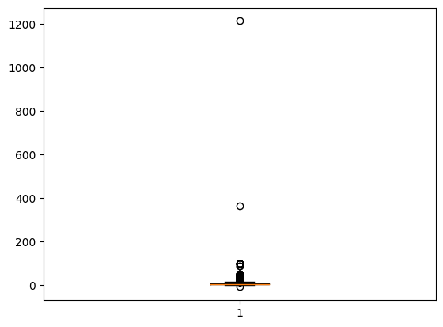

```python
plt.boxplot(data2['CURRENT_DEMERITS'])
```

```python
demerit_bins = [0, 30, 40, 50,60,float('inf')]
demerit_labels = ['0-30', '31-40', '41-50', '51-60','70+']
data2['Demerit_Bucket'] = pd.cut(data2['CURRENT_DEMERITS'], bins=demerit_bins, labels=demerit_labels, include_lowest=True)
```

```python
Demerit_count=data2.groupby(by='Demerit_Bucket').count().reset_index().iloc[::,:2].copy()
Demerit_count=Demerit_count.rename(columns={'RESTAURANT_CATEGORY':'Count'}).copy()
Demerit_count
```

|  | Demerit_Bucket | Count |
| --- | --- | --- |
| 0 | 0-30 | 14818 |
| 1 | 31-40 | 31 |
| 2 | 41-50 | 19 |
| 3 | 51-60 | 6 |
| 4 | 70+ | 12 |

```python
data2=data2[data2['CURRENT_DEMERITS']<=50].copy()
data2
```

|  | RESTAURANT_CATEGORY | CURRENT_DEMERITS | CURRENT_GRADE | EMPLOYEE_COUNT | MEDIAN_EMPLOYEE_AGE | MEDIAN_EMPLOYEE_TENURE | INSPECTION_DEMERITS | FIRST_VIOLATION | SECOND_VIOLATION | THIRD_VIOLATION | FIRST_VIOLATION_TYPE | SECOND_VIOLATION_TYPE | THIRD_VIOLATION_TYPE | NUMBER_OF_VIOLATIONS | NEXT_INSPECTION_GRADE_C_OR_BELOW | Age_Bucket | Demerit_Bucket |
| --- | --- | --- | --- | --- | --- | --- | --- | --- | --- | --- | --- | --- | --- | --- | --- | --- | --- |
| 0 | Food Truck | 0.0 | C | 25.0 | 27.959983 | 13.004886 | 11 | 204.0 | 215.0 | 302.0 | Critical | Major | Imminent Health Hazard | 4 | 0.0 | 0-30 | 0-30 |
| 1 | Restaurant | 3.0 | A | 7.0 | 27.719365 | 3.922086 | 9 | 214.0 | 216.0 | 229.0 | Major | Major | Non-Major | 5 | 0.0 | 0-30 | 0-30 |
| 2 | Restaurant | 8.0 | A | 23.0 | 26.442637 | 10.312777 | 9 | 202.0 | 215.0 | 233.0 | Critical | Major | Non-Major | 3 | 1.0 | 0-30 | 0-30 |
| 3 | Elementary School Kitchen | 0.0 | A | 14.0 | 33.988293 | 4.163975 | 5 | 214.0 | 230.0 | 233.0 | Major | Non-Major | Non-Major | 3 | 0.0 | 31-40 | 0-30 |
| 5 | Bar / Tavern | 3.0 | A | 43.0 | 25.947206 | 3.839934 | 17 | 206.0 | 211.0 | 215.0 | Critical | Major | Major | 7 | 0.0 | 0-30 | 0-30 |
| ... | ... | ... | ... | ... | ... | ... | ... | ... | ... | ... | ... | ... | ... | ... | ... | ... | ... |
| 17190 | Restaurant | 9.0 | A | 9.0 | 33.383773 | 4.830165 | 4 | 18.0 | 28.0 | 36.0 | Non-Major | Non-Major | Non-Major | 4 | 0.0 | 31-40 | 0-30 |
| 17191 | Restaurant | 9.0 | A | 9.0 | 33.383773 | 4.830165 | 4 | 18.0 | 28.0 | 36.0 | Non-Major | Non-Major | Non-Major | 4 | 0.0 | 31-40 | 0-30 |
| 17192 | Restaurant | 9.0 | A | 9.0 | 33.383773 | 4.830165 | 4 | 18.0 | 28.0 | 36.0 | Non-Major | Non-Major | Non-Major | 4 | 0.0 | 31-40 | 0-30 |
| 17193 | Restaurant | 9.0 | A | 9.0 | 33.383773 | 4.830165 | 4 | 18.0 | 28.0 | 36.0 | Non-Major | Non-Major | Non-Major | 4 | 0.0 | 31-40 | 0-30 |
| 17194 | Restaurant | 9.0 | A | 9.0 | 33.383773 | 4.830165 | 4 | 18.0 | 28.0 | 36.0 | Non-Major | Non-Major | Non-Major | 4 | 0.0 | 31-40 | 0-30 |

14869 rows × 17 columns

```python
grade_wisecount=data2.groupby(['CURRENT_GRADE']).count().reset_index().iloc[::,:2].copy()
grade_wisecount=grade_wisecount.rename(columns={'RESTAURANT_CATEGORY':'Count'}).copy()
grade_wisecount
```

|  | CURRENT_GRADE | Count |
| --- | --- | --- |
| 0 | .\<><1@#&\| | 1 |
| 1 | 7 | 1 |
| 2 | A | 12993 |
| 3 | AA | 1 |
| 4 | AAA | 1 |
| 5 | Ayyyyyyy | 1 |
| 6 | B | 212 |
| 7 | C | 1564 |
| 8 | C+ | 1 |
| 9 | CC | 1 |
| 10 | Cc | 1 |
| 11 | N | 7 |
| 12 | O | 31 |
| 13 | UPN | 1 |
| 14 | X | 53 |

```python
category_mapping = {
    'A': 'A',
    'A+': 'A',
    'AA': 'A',
    'AAA': 'A',
    'Ayyyyyyy':'A',
    'B': 'B',
    'C': 'C',
    'C+': 'C',
    'CC': 'C',
    'Cc': 'C'
}
categories_to_keep = ['A', 'B', 'C']
```

```python
data2['CURRENT_GRADE'] = data2['CURRENT_GRADE'].replace(category_mapping)
```

```python
data2 = data2[data2['CURRENT_GRADE'].isin(categories_to_keep)].copy()
```

```python
data2
```

|  | RESTAURANT_CATEGORY | CURRENT_DEMERITS | CURRENT_GRADE | EMPLOYEE_COUNT | MEDIAN_EMPLOYEE_AGE | MEDIAN_EMPLOYEE_TENURE | INSPECTION_DEMERITS | FIRST_VIOLATION | SECOND_VIOLATION | THIRD_VIOLATION | FIRST_VIOLATION_TYPE | SECOND_VIOLATION_TYPE | THIRD_VIOLATION_TYPE | NUMBER_OF_VIOLATIONS | NEXT_INSPECTION_GRADE_C_OR_BELOW | Age_Bucket | Demerit_Bucket |
| --- | --- | --- | --- | --- | --- | --- | --- | --- | --- | --- | --- | --- | --- | --- | --- | --- | --- |
| 0 | Food Truck | 0.0 | C | 25.0 | 27.959983 | 13.004886 | 11 | 204.0 | 215.0 | 302.0 | Critical | Major | Imminent Health Hazard | 4 | 0.0 | 0-30 | 0-30 |
| 1 | Restaurant | 3.0 | A | 7.0 | 27.719365 | 3.922086 | 9 | 214.0 | 216.0 | 229.0 | Major | Major | Non-Major | 5 | 0.0 | 0-30 | 0-30 |
| 2 | Restaurant | 8.0 | A | 23.0 | 26.442637 | 10.312777 | 9 | 202.0 | 215.0 | 233.0 | Critical | Major | Non-Major | 3 | 1.0 | 0-30 | 0-30 |
| 3 | Elementary School Kitchen | 0.0 | A | 14.0 | 33.988293 | 4.163975 | 5 | 214.0 | 230.0 | 233.0 | Major | Non-Major | Non-Major | 3 | 0.0 | 31-40 | 0-30 |
| 5 | Bar / Tavern | 3.0 | A | 43.0 | 25.947206 | 3.839934 | 17 | 206.0 | 211.0 | 215.0 | Critical | Major | Major | 7 | 0.0 | 0-30 | 0-30 |
| ... | ... | ... | ... | ... | ... | ... | ... | ... | ... | ... | ... | ... | ... | ... | ... | ... | ... |
| 17190 | Restaurant | 9.0 | A | 9.0 | 33.383773 | 4.830165 | 4 | 18.0 | 28.0 | 36.0 | Non-Major | Non-Major | Non-Major | 4 | 0.0 | 31-40 | 0-30 |
| 17191 | Restaurant | 9.0 | A | 9.0 | 33.383773 | 4.830165 | 4 | 18.0 | 28.0 | 36.0 | Non-Major | Non-Major | Non-Major | 4 | 0.0 | 31-40 | 0-30 |
| 17192 | Restaurant | 9.0 | A | 9.0 | 33.383773 | 4.830165 | 4 | 18.0 | 28.0 | 36.0 | Non-Major | Non-Major | Non-Major | 4 | 0.0 | 31-40 | 0-30 |
| 17193 | Restaurant | 9.0 | A | 9.0 | 33.383773 | 4.830165 | 4 | 18.0 | 28.0 | 36.0 | Non-Major | Non-Major | Non-Major | 4 | 0.0 | 31-40 | 0-30 |
| 17194 | Restaurant | 9.0 | A | 9.0 | 33.383773 | 4.830165 | 4 | 18.0 | 28.0 | 36.0 | Non-Major | Non-Major | Non-Major | 4 | 0.0 | 31-40 | 0-30 |

14775 rows × 17 columns

```python
data2['INSPECTION_DEMERITS'] = data2['INSPECTION_DEMERITS'].apply(custom_convert)
data2['INSPECTION_DEMERITS'] = pd.to_numeric(data2['INSPECTION_DEMERITS'], errors='coerce')

# Filter the DataFrame to retain rows where 'Value_Column' contains float values
data2 = data2.dropna(subset=['INSPECTION_DEMERITS']).copy()
data2=data2[data2['INSPECTION_DEMERITS']>0].copy()
```

```python
data2['INSPECTION_DEMERITS']
#print(max(data2['INSPECTION_DEMERITS']))
```

```
0        11.0
1         9.0
2         9.0
3         5.0
5        17.0
         ...
17190     4.0
17191     4.0
17192     4.0
17193     4.0
17194     4.0
Name: INSPECTION_DEMERITS, Length: 14763, dtype: float64
```

```python
IN_demerit_bins = [0, 30, 40, 50,60,float('inf')]
IN_demerit_labels = ['0-30', '31-40', '41-50', '51-60','70+']
data2['INSPECTION_DEMERITS_bucket'] = pd.cut(data2['INSPECTION_DEMERITS'], bins=IN_demerit_bins, labels=IN_demerit_labels, include_lowest=True)
```

```python
IN_Demerit_count=data2.groupby(by='INSPECTION_DEMERITS_bucket').count().reset_index().iloc[::,:2]
IN_Demerit_count
```

|  | INSPECTION_DEMERITS_bucket | RESTAURANT_CATEGORY |
| --- | --- | --- |
| 0 | 0-30 | 14060 |
| 1 | 31-40 | 610 |
| 2 | 41-50 | 65 |
| 3 | 51-60 | 21 |
| 4 | 70+ | 7 |

```python
data2=data2[data2['INSPECTION_DEMERITS']<=50].copy()
data2
```

|  | RESTAURANT_CATEGORY | CURRENT_DEMERITS | CURRENT_GRADE | EMPLOYEE_COUNT | MEDIAN_EMPLOYEE_AGE | MEDIAN_EMPLOYEE_TENURE | INSPECTION_DEMERITS | FIRST_VIOLATION | SECOND_VIOLATION | THIRD_VIOLATION | FIRST_VIOLATION_TYPE | SECOND_VIOLATION_TYPE | THIRD_VIOLATION_TYPE | NUMBER_OF_VIOLATIONS | NEXT_INSPECTION_GRADE_C_OR_BELOW | Age_Bucket | Demerit_Bucket | INSPECTION_DEMERITS_bucket |
| --- | --- | --- | --- | --- | --- | --- | --- | --- | --- | --- | --- | --- | --- | --- | --- | --- | --- | --- |
| 0 | Food Truck | 0.0 | C | 25.0 | 27.959983 | 13.004886 | 11.0 | 204.0 | 215.0 | 302.0 | Critical | Major | Imminent Health Hazard | 4 | 0.0 | 0-30 | 0-30 | 0-30 |
| 1 | Restaurant | 3.0 | A | 7.0 | 27.719365 | 3.922086 | 9.0 | 214.0 | 216.0 | 229.0 | Major | Major | Non-Major | 5 | 0.0 | 0-30 | 0-30 | 0-30 |
| 2 | Restaurant | 8.0 | A | 23.0 | 26.442637 | 10.312777 | 9.0 | 202.0 | 215.0 | 233.0 | Critical | Major | Non-Major | 3 | 1.0 | 0-30 | 0-30 | 0-30 |
| 3 | Elementary School Kitchen | 0.0 | A | 14.0 | 33.988293 | 4.163975 | 5.0 | 214.0 | 230.0 | 233.0 | Major | Non-Major | Non-Major | 3 | 0.0 | 31-40 | 0-30 | 0-30 |
| 5 | Bar / Tavern | 3.0 | A | 43.0 | 25.947206 | 3.839934 | 17.0 | 206.0 | 211.0 | 215.0 | Critical | Major | Major | 7 | 0.0 | 0-30 | 0-30 | 0-30 |
| ... | ... | ... | ... | ... | ... | ... | ... | ... | ... | ... | ... | ... | ... | ... | ... | ... | ... | ... |
| 17190 | Restaurant | 9.0 | A | 9.0 | 33.383773 | 4.830165 | 4.0 | 18.0 | 28.0 | 36.0 | Non-Major | Non-Major | Non-Major | 4 | 0.0 | 31-40 | 0-30 | 0-30 |
| 17191 | Restaurant | 9.0 | A | 9.0 | 33.383773 | 4.830165 | 4.0 | 18.0 | 28.0 | 36.0 | Non-Major | Non-Major | Non-Major | 4 | 0.0 | 31-40 | 0-30 | 0-30 |
| 17192 | Restaurant | 9.0 | A | 9.0 | 33.383773 | 4.830165 | 4.0 | 18.0 | 28.0 | 36.0 | Non-Major | Non-Major | Non-Major | 4 | 0.0 | 31-40 | 0-30 | 0-30 |
| 17193 | Restaurant | 9.0 | A | 9.0 | 33.383773 | 4.830165 | 4.0 | 18.0 | 28.0 | 36.0 | Non-Major | Non-Major | Non-Major | 4 | 0.0 | 31-40 | 0-30 | 0-30 |
| 17194 | Restaurant | 9.0 | A | 9.0 | 33.383773 | 4.830165 | 4.0 | 18.0 | 28.0 | 36.0 | Non-Major | Non-Major | Non-Major | 4 | 0.0 | 31-40 | 0-30 | 0-30 |

14735 rows × 18 columns

```python
data2['RESTAURANT_CATEGORY'].unique()
```

```
array(['Food Truck', 'Restaurant', 'Elementary School Kitchen',
       'Bar / Tavern', 'Pantry', 'Special Kitchen', 'Bakery Sales',
       'Food Trucks / Mobile Vendor', 'Buffet', 'Portable Unit',
       'Concessions', 'Kitchen Bakery', 'Produce Market', 'Bar / TaVen',
       'Grocery Store Sampling', 'Banquet Support', 'Caterer',
       'Bark / Tavern', 'Banquet Kitchen', 'Meat/Poultry/Seafood',
       'Garde Manger', 'Portable Bar', 'Institutional Food Service',
       'Gas Station', 'Vegetable Prep', 'Childcare Kitchens',
       'Confection', 'Main Kitchen', 'Barbeque', 'Farmers Market',
       'Self-Service Food Truck', 'Beer Bar', 'Jimmy Buffett'],
      dtype=object)
```

```python
data3=data2.copy()
data3
```

|  | RESTAURANT_CATEGORY | CURRENT_DEMERITS | CURRENT_GRADE | EMPLOYEE_COUNT | MEDIAN_EMPLOYEE_AGE | MEDIAN_EMPLOYEE_TENURE | INSPECTION_DEMERITS | FIRST_VIOLATION | SECOND_VIOLATION | THIRD_VIOLATION | FIRST_VIOLATION_TYPE | SECOND_VIOLATION_TYPE | THIRD_VIOLATION_TYPE | NUMBER_OF_VIOLATIONS | NEXT_INSPECTION_GRADE_C_OR_BELOW | Age_Bucket | Demerit_Bucket | INSPECTION_DEMERITS_bucket |
| --- | --- | --- | --- | --- | --- | --- | --- | --- | --- | --- | --- | --- | --- | --- | --- | --- | --- | --- |
| 0 | Food Truck | 0.0 | C | 25.0 | 27.959983 | 13.004886 | 11.0 | 204.0 | 215.0 | 302.0 | Critical | Major | Imminent Health Hazard | 4 | 0.0 | 0-30 | 0-30 | 0-30 |
| 1 | Restaurant | 3.0 | A | 7.0 | 27.719365 | 3.922086 | 9.0 | 214.0 | 216.0 | 229.0 | Major | Major | Non-Major | 5 | 0.0 | 0-30 | 0-30 | 0-30 |
| 2 | Restaurant | 8.0 | A | 23.0 | 26.442637 | 10.312777 | 9.0 | 202.0 | 215.0 | 233.0 | Critical | Major | Non-Major | 3 | 1.0 | 0-30 | 0-30 | 0-30 |
| 3 | Elementary School Kitchen | 0.0 | A | 14.0 | 33.988293 | 4.163975 | 5.0 | 214.0 | 230.0 | 233.0 | Major | Non-Major | Non-Major | 3 | 0.0 | 31-40 | 0-30 | 0-30 |
| 5 | Bar / Tavern | 3.0 | A | 43.0 | 25.947206 | 3.839934 | 17.0 | 206.0 | 211.0 | 215.0 | Critical | Major | Major | 7 | 0.0 | 0-30 | 0-30 | 0-30 |
| ... | ... | ... | ... | ... | ... | ... | ... | ... | ... | ... | ... | ... | ... | ... | ... | ... | ... | ... |
| 17190 | Restaurant | 9.0 | A | 9.0 | 33.383773 | 4.830165 | 4.0 | 18.0 | 28.0 | 36.0 | Non-Major | Non-Major | Non-Major | 4 | 0.0 | 31-40 | 0-30 | 0-30 |
| 17191 | Restaurant | 9.0 | A | 9.0 | 33.383773 | 4.830165 | 4.0 | 18.0 | 28.0 | 36.0 | Non-Major | Non-Major | Non-Major | 4 | 0.0 | 31-40 | 0-30 | 0-30 |
| 17192 | Restaurant | 9.0 | A | 9.0 | 33.383773 | 4.830165 | 4.0 | 18.0 | 28.0 | 36.0 | Non-Major | Non-Major | Non-Major | 4 | 0.0 | 31-40 | 0-30 | 0-30 |
| 17193 | Restaurant | 9.0 | A | 9.0 | 33.383773 | 4.830165 | 4.0 | 18.0 | 28.0 | 36.0 | Non-Major | Non-Major | Non-Major | 4 | 0.0 | 31-40 | 0-30 | 0-30 |
| 17194 | Restaurant | 9.0 | A | 9.0 | 33.383773 | 4.830165 | 4.0 | 18.0 | 28.0 | 36.0 | Non-Major | Non-Major | Non-Major | 4 | 0.0 | 31-40 | 0-30 | 0-30 |

14735 rows × 18 columns

```python
category_mapping1 = {
    'Food Truck': 'Food Service Establishments',
    'Restaurant': 'Food Service Establishments',
    'Bar / Tavern': 'Food Service Establishments',
    'Bar / TaVen': 'Food Service Establishments',
    'Bark / Tavern':'Food Service Establishments',
    'Pantry': 'Food Service Establishments',
    'Special Kitchen': 'Food Service Establishments',
    'Bakery Sales': 'Food Service Establishments',
    'Buffet': 'Food Service Establishments',
    'Concessions': 'Food Service Establishments',
    'Kitchen Bakery':'Food Service Establishments',
    'Produce Market':'Food Service Establishments',
    'Banquet Support':'Food Service Establishments',
    'Caterer':'Food Service Establishments',
    'Banquet Kitchen':'Food Service Establishments',
    'Food Trucks / Mobile Vendor':'Food Service Establishments',
    'Confection':'Food Service Establishments',
    'Main Kitchen':'Food Service Establishments',
    'Barbeque':'Food Service Establishments',
    'Childcare Kitchens':'Food Service Establishments',
    'Farmers Market':'Food Service Establishments',
    'Self-Service Food Truck':'Food Service Establishments',

    'Grocery Store Sampling':'Retail Food Outlets',
    'Gas Station':'Retail Food Outlets',

    'Elementary School Kitchen':'Food Preparation and Cooking',
    'Meat/Poultry/Seafood':'Food Preparation and Cooking',
    'Garde Manger':'Food Preparation and Cooking',
    'Vegetable Prep':'Food Preparation and Cooking',

    'Portable Unit':'Beverage and Bar Service',
    'Portable Bar':'Beverage and Bar Service',
    'Institutional Food Service':'Beverage and Bar Service',
    'Jimmy Buffett':'Beverage and Bar Service',
    'Beer Bar':'Beverage and Bar Service'

}
```

```python
data3['RESTAURANT_CATEGORY'] = data3['RESTAURANT_CATEGORY'].replace(category_mapping1)
```

```python
data3['RESTAURANT_CATEGORY'].unique()
```

```
array(['Food Service Establishments', 'Food Preparation and Cooking',
       'Beverage and Bar Service', 'Retail Food Outlets'], dtype=object)
```

```python
data3
```

|  | RESTAURANT_CATEGORY | CURRENT_DEMERITS | CURRENT_GRADE | EMPLOYEE_COUNT | MEDIAN_EMPLOYEE_AGE | MEDIAN_EMPLOYEE_TENURE | INSPECTION_DEMERITS | FIRST_VIOLATION | SECOND_VIOLATION | THIRD_VIOLATION | FIRST_VIOLATION_TYPE | SECOND_VIOLATION_TYPE | THIRD_VIOLATION_TYPE | NUMBER_OF_VIOLATIONS | NEXT_INSPECTION_GRADE_C_OR_BELOW | Age_Bucket | Demerit_Bucket | INSPECTION_DEMERITS_bucket |
| --- | --- | --- | --- | --- | --- | --- | --- | --- | --- | --- | --- | --- | --- | --- | --- | --- | --- | --- |
| 0 | Food Service Establishments | 0.0 | C | 25.0 | 27.959983 | 13.004886 | 11.0 | 204.0 | 215.0 | 302.0 | Critical | Major | Imminent Health Hazard | 4 | 0.0 | 0-30 | 0-30 | 0-30 |
| 1 | Food Service Establishments | 3.0 | A | 7.0 | 27.719365 | 3.922086 | 9.0 | 214.0 | 216.0 | 229.0 | Major | Major | Non-Major | 5 | 0.0 | 0-30 | 0-30 | 0-30 |
| 2 | Food Service Establishments | 8.0 | A | 23.0 | 26.442637 | 10.312777 | 9.0 | 202.0 | 215.0 | 233.0 | Critical | Major | Non-Major | 3 | 1.0 | 0-30 | 0-30 | 0-30 |
| 3 | Food Preparation and Cooking | 0.0 | A | 14.0 | 33.988293 | 4.163975 | 5.0 | 214.0 | 230.0 | 233.0 | Major | Non-Major | Non-Major | 3 | 0.0 | 31-40 | 0-30 | 0-30 |
| 5 | Food Service Establishments | 3.0 | A | 43.0 | 25.947206 | 3.839934 | 17.0 | 206.0 | 211.0 | 215.0 | Critical | Major | Major | 7 | 0.0 | 0-30 | 0-30 | 0-30 |
| ... | ... | ... | ... | ... | ... | ... | ... | ... | ... | ... | ... | ... | ... | ... | ... | ... | ... | ... |
| 17190 | Food Service Establishments | 9.0 | A | 9.0 | 33.383773 | 4.830165 | 4.0 | 18.0 | 28.0 | 36.0 | Non-Major | Non-Major | Non-Major | 4 | 0.0 | 31-40 | 0-30 | 0-30 |
| 17191 | Food Service Establishments | 9.0 | A | 9.0 | 33.383773 | 4.830165 | 4.0 | 18.0 | 28.0 | 36.0 | Non-Major | Non-Major | Non-Major | 4 | 0.0 | 31-40 | 0-30 | 0-30 |
| 17192 | Food Service Establishments | 9.0 | A | 9.0 | 33.383773 | 4.830165 | 4.0 | 18.0 | 28.0 | 36.0 | Non-Major | Non-Major | Non-Major | 4 | 0.0 | 31-40 | 0-30 | 0-30 |
| 17193 | Food Service Establishments | 9.0 | A | 9.0 | 33.383773 | 4.830165 | 4.0 | 18.0 | 28.0 | 36.0 | Non-Major | Non-Major | Non-Major | 4 | 0.0 | 31-40 | 0-30 | 0-30 |
| 17194 | Food Service Establishments | 9.0 | A | 9.0 | 33.383773 | 4.830165 | 4.0 | 18.0 | 28.0 | 36.0 | Non-Major | Non-Major | Non-Major | 4 | 0.0 | 31-40 | 0-30 | 0-30 |

14735 rows × 18 columns

```python
rest_grade=pd.DataFrame(data3.groupby(by='RESTAURANT_CATEGORY')['NEXT_INSPECTION_GRADE_C_OR_BELOW'].sum()).reset_index()
rest_grade
```

|  | RESTAURANT_CATEGORY | NEXT_INSPECTION_GRADE_C_OR_BELOW |
| --- | --- | --- |
| 0 | Beverage and Bar Service | 42.0 |
| 1 | Food Preparation and Cooking | 28.0 |
| 2 | Food Service Establishments | 2163.0 |
| 3 | Retail Food Outlets | 10.0 |

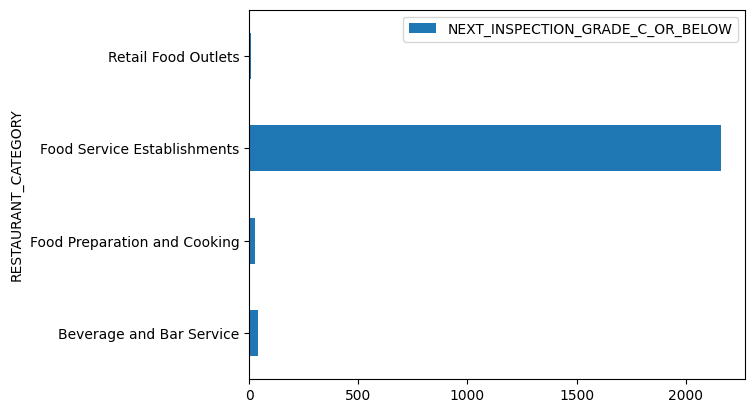

```python
rest_grade.plot.barh('RESTAURANT_CATEGORY',rot=0)
```

```python
data3.groupby('FIRST_VIOLATION_TYPE').count().iloc[::,:1].reset_index()
```

|  | FIRST_VIOLATION_TYPE | RESTAURANT_CATEGORY |
| --- | --- | --- |
| 0 | Critical | 6362 |
| 1 | Kritical | 10 |
| 2 | Major | 5783 |
| 3 | Major-ish | 1 |
| 4 | Non-Major | 2568 |
| 5 | Not Critical Enough | 3 |
| 6 | Not Sure | 1 |
| 7 | Supercalifragilisticexpialidocius | 7 |

```python
category_mapping2 = {
    'Critical': 'Critical',
    'Kritical': 'Critical',
    'Major': 'Major',
    'Non-Major': 'Non-Major'
}
categories_to_keep2 = ['Critical', 'Major', 'Non-Major']
```

```python
data3['FIRST_VIOLATION_TYPE'] = data3['FIRST_VIOLATION_TYPE'].replace(category_mapping2)
```

```python
data3 = data3[data3['FIRST_VIOLATION_TYPE'].isin(categories_to_keep2)].copy()
data3
```

|  | RESTAURANT_CATEGORY | CURRENT_DEMERITS | CURRENT_GRADE | EMPLOYEE_COUNT | MEDIAN_EMPLOYEE_AGE | MEDIAN_EMPLOYEE_TENURE | INSPECTION_DEMERITS | FIRST_VIOLATION | SECOND_VIOLATION | THIRD_VIOLATION | FIRST_VIOLATION_TYPE | SECOND_VIOLATION_TYPE | THIRD_VIOLATION_TYPE | NUMBER_OF_VIOLATIONS | NEXT_INSPECTION_GRADE_C_OR_BELOW | Age_Bucket | Demerit_Bucket | INSPECTION_DEMERITS_bucket |
| --- | --- | --- | --- | --- | --- | --- | --- | --- | --- | --- | --- | --- | --- | --- | --- | --- | --- | --- |
| 0 | Food Service Establishments | 0.0 | C | 25.0 | 27.959983 | 13.004886 | 11.0 | 204.0 | 215.0 | 302.0 | Critical | Major | Imminent Health Hazard | 4 | 0.0 | 0-30 | 0-30 | 0-30 |
| 1 | Food Service Establishments | 3.0 | A | 7.0 | 27.719365 | 3.922086 | 9.0 | 214.0 | 216.0 | 229.0 | Major | Major | Non-Major | 5 | 0.0 | 0-30 | 0-30 | 0-30 |
| 2 | Food Service Establishments | 8.0 | A | 23.0 | 26.442637 | 10.312777 | 9.0 | 202.0 | 215.0 | 233.0 | Critical | Major | Non-Major | 3 | 1.0 | 0-30 | 0-30 | 0-30 |
| 3 | Food Preparation and Cooking | 0.0 | A | 14.0 | 33.988293 | 4.163975 | 5.0 | 214.0 | 230.0 | 233.0 | Major | Non-Major | Non-Major | 3 | 0.0 | 31-40 | 0-30 | 0-30 |
| 5 | Food Service Establishments | 3.0 | A | 43.0 | 25.947206 | 3.839934 | 17.0 | 206.0 | 211.0 | 215.0 | Critical | Major | Major | 7 | 0.0 | 0-30 | 0-30 | 0-30 |
| ... | ... | ... | ... | ... | ... | ... | ... | ... | ... | ... | ... | ... | ... | ... | ... | ... | ... | ... |
| 17190 | Food Service Establishments | 9.0 | A | 9.0 | 33.383773 | 4.830165 | 4.0 | 18.0 | 28.0 | 36.0 | Non-Major | Non-Major | Non-Major | 4 | 0.0 | 31-40 | 0-30 | 0-30 |
| 17191 | Food Service Establishments | 9.0 | A | 9.0 | 33.383773 | 4.830165 | 4.0 | 18.0 | 28.0 | 36.0 | Non-Major | Non-Major | Non-Major | 4 | 0.0 | 31-40 | 0-30 | 0-30 |
| 17192 | Food Service Establishments | 9.0 | A | 9.0 | 33.383773 | 4.830165 | 4.0 | 18.0 | 28.0 | 36.0 | Non-Major | Non-Major | Non-Major | 4 | 0.0 | 31-40 | 0-30 | 0-30 |
| 17193 | Food Service Establishments | 9.0 | A | 9.0 | 33.383773 | 4.830165 | 4.0 | 18.0 | 28.0 | 36.0 | Non-Major | Non-Major | Non-Major | 4 | 0.0 | 31-40 | 0-30 | 0-30 |
| 17194 | Food Service Establishments | 9.0 | A | 9.0 | 33.383773 | 4.830165 | 4.0 | 18.0 | 28.0 | 36.0 | Non-Major | Non-Major | Non-Major | 4 | 0.0 | 31-40 | 0-30 | 0-30 |

14723 rows × 18 columns

```python
data3.groupby('FIRST_VIOLATION_TYPE').count().iloc[::,:1].reset_index()
```

|  | FIRST_VIOLATION_TYPE | RESTAURANT_CATEGORY |
| --- | --- | --- |
| 0 | Critical | 6372 |
| 1 | Major | 5783 |
| 2 | Non-Major | 2568 |

```python
data3.groupby('SECOND_VIOLATION_TYPE').count().iloc[::,:1].reset_index()
```

|  | SECOND_VIOLATION_TYPE | RESTAURANT_CATEGORY |
| --- | --- | --- |
| 0 | Critical | 2529 |
| 1 | I have no idea | 1 |
| 2 | Imminent Health Hazard | 2 |
| 3 | Kritical | 4 |
| 4 | Major | 7075 |
| 5 | Non-Major | 5111 |
| 6 | Supercritical | 1 |

```python
data3['SECOND_VIOLATION_TYPE'] = data3['SECOND_VIOLATION_TYPE'].replace(category_mapping2)
```

```python
data3 = data3[data3['SECOND_VIOLATION_TYPE'].isin(categories_to_keep2)].copy()
```

```python
data3.groupby('SECOND_VIOLATION_TYPE').count().iloc[::,:1].reset_index()
```

|  | SECOND_VIOLATION_TYPE | RESTAURANT_CATEGORY |
| --- | --- | --- |
| 0 | Critical | 2533 |
| 1 | Major | 7075 |
| 2 | Non-Major | 5111 |

```python
data3.groupby('THIRD_VIOLATION_TYPE').count().iloc[::,:1].reset_index()
```

|  | THIRD_VIOLATION_TYPE | RESTAURANT_CATEGORY |
| --- | --- | --- |
| 0 | 789wre | 1 |
| 1 | Banana | 1 |
| 2 | Critical | 711 |
| 3 | Down Yonder | 1 |
| 4 | Imminent Health Hazard | 31 |
| 5 | Kritical | 2 |
| 6 | Major | 6494 |
| 7 | Non-MaJoRNonMajorNonmajor | 7 |
| 8 | Non-Major | 7465 |
| 9 | Whoa | 6 |

```python
category_mapping3 = {
    'Critical': 'Critical',
    'Kritical': 'Critical',
    'Imminent Health Hazard':'Critical',
    'Major': 'Major',
    'Non-Major': 'Non-Major'
}
categories_to_keep3 = ['Critical', 'Major', 'Non-Major']
```

```python
data3['THIRD_VIOLATION_TYPE'] = data3['THIRD_VIOLATION_TYPE'].replace(category_mapping3)
data3 = data3[data3['THIRD_VIOLATION_TYPE'].isin(categories_to_keep3)].copy()
data3
```

|  | RESTAURANT_CATEGORY | CURRENT_DEMERITS | CURRENT_GRADE | EMPLOYEE_COUNT | MEDIAN_EMPLOYEE_AGE | MEDIAN_EMPLOYEE_TENURE | INSPECTION_DEMERITS | FIRST_VIOLATION | SECOND_VIOLATION | THIRD_VIOLATION | FIRST_VIOLATION_TYPE | SECOND_VIOLATION_TYPE | THIRD_VIOLATION_TYPE | NUMBER_OF_VIOLATIONS | NEXT_INSPECTION_GRADE_C_OR_BELOW | Age_Bucket | Demerit_Bucket | INSPECTION_DEMERITS_bucket |
| --- | --- | --- | --- | --- | --- | --- | --- | --- | --- | --- | --- | --- | --- | --- | --- | --- | --- | --- |
| 0 | Food Service Establishments | 0.0 | C | 25.0 | 27.959983 | 13.004886 | 11.0 | 204.0 | 215.0 | 302.0 | Critical | Major | Critical | 4 | 0.0 | 0-30 | 0-30 | 0-30 |
| 1 | Food Service Establishments | 3.0 | A | 7.0 | 27.719365 | 3.922086 | 9.0 | 214.0 | 216.0 | 229.0 | Major | Major | Non-Major | 5 | 0.0 | 0-30 | 0-30 | 0-30 |
| 2 | Food Service Establishments | 8.0 | A | 23.0 | 26.442637 | 10.312777 | 9.0 | 202.0 | 215.0 | 233.0 | Critical | Major | Non-Major | 3 | 1.0 | 0-30 | 0-30 | 0-30 |
| 3 | Food Preparation and Cooking | 0.0 | A | 14.0 | 33.988293 | 4.163975 | 5.0 | 214.0 | 230.0 | 233.0 | Major | Non-Major | Non-Major | 3 | 0.0 | 31-40 | 0-30 | 0-30 |
| 5 | Food Service Establishments | 3.0 | A | 43.0 | 25.947206 | 3.839934 | 17.0 | 206.0 | 211.0 | 215.0 | Critical | Major | Major | 7 | 0.0 | 0-30 | 0-30 | 0-30 |
| ... | ... | ... | ... | ... | ... | ... | ... | ... | ... | ... | ... | ... | ... | ... | ... | ... | ... | ... |
| 17190 | Food Service Establishments | 9.0 | A | 9.0 | 33.383773 | 4.830165 | 4.0 | 18.0 | 28.0 | 36.0 | Non-Major | Non-Major | Non-Major | 4 | 0.0 | 31-40 | 0-30 | 0-30 |
| 17191 | Food Service Establishments | 9.0 | A | 9.0 | 33.383773 | 4.830165 | 4.0 | 18.0 | 28.0 | 36.0 | Non-Major | Non-Major | Non-Major | 4 | 0.0 | 31-40 | 0-30 | 0-30 |
| 17192 | Food Service Establishments | 9.0 | A | 9.0 | 33.383773 | 4.830165 | 4.0 | 18.0 | 28.0 | 36.0 | Non-Major | Non-Major | Non-Major | 4 | 0.0 | 31-40 | 0-30 | 0-30 |
| 17193 | Food Service Establishments | 9.0 | A | 9.0 | 33.383773 | 4.830165 | 4.0 | 18.0 | 28.0 | 36.0 | Non-Major | Non-Major | Non-Major | 4 | 0.0 | 31-40 | 0-30 | 0-30 |
| 17194 | Food Service Establishments | 9.0 | A | 9.0 | 33.383773 | 4.830165 | 4.0 | 18.0 | 28.0 | 36.0 | Non-Major | Non-Major | Non-Major | 4 | 0.0 | 31-40 | 0-30 | 0-30 |

14703 rows × 18 columns

```python
data3.groupby('THIRD_VIOLATION_TYPE').count().iloc[::,:1].reset_index()
```

|  | THIRD_VIOLATION_TYPE | RESTAURANT_CATEGORY |
| --- | --- | --- |
| 0 | Critical | 744 |
| 1 | Major | 6494 |
| 2 | Non-Major | 7465 |

```python
data3['NUMBER_OF_VIOLATIONS']=pd.to_numeric(data3['NUMBER_OF_VIOLATIONS'])
```

```
{'whiskers': [<matplotlib.lines.Line2D at 0x7841919d67d0>,
 'caps': [<matplotlib.lines.Line2D at 0x7841919d6d10>,
 'boxes': [<matplotlib.lines.Line2D at 0x7841919d6530>],
 'medians': [<matplotlib.lines.Line2D at 0x7841919d7250>],
 'fliers': [<matplotlib.lines.Line2D at 0x7841919d74f0>],
 'means': []}
```

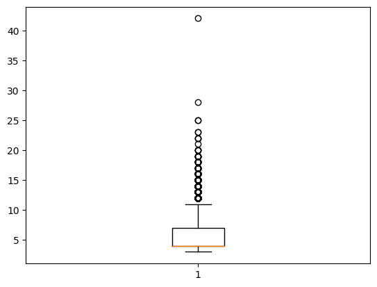

```python
plt.boxplot(data3['NUMBER_OF_VIOLATIONS'])
```

```
{'whiskers': [<matplotlib.lines.Line2D at 0x7841939c6b60>,
 'caps': [<matplotlib.lines.Line2D at 0x7841939c70a0>,
 'boxes': [<matplotlib.lines.Line2D at 0x7841939c68c0>],
 'medians': [<matplotlib.lines.Line2D at 0x7841939c75e0>],
 'fliers': [<matplotlib.lines.Line2D at 0x7841939c7880>],
 'means': []}
```

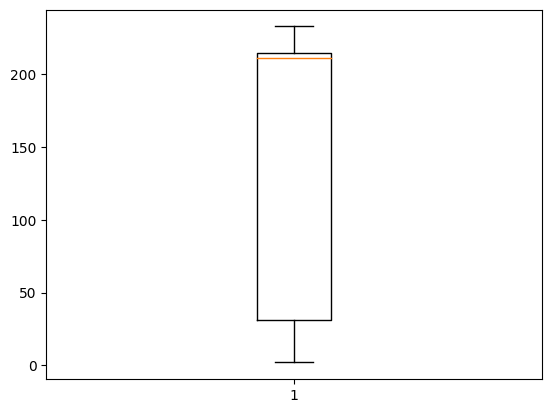

```python
plt.boxplot(data3['SECOND_VIOLATION'])
```

```
{'whiskers': [<matplotlib.lines.Line2D at 0x784193840880>,
 'caps': [<matplotlib.lines.Line2D at 0x784193840dc0>,
 'boxes': [<matplotlib.lines.Line2D at 0x7841938405e0>],
 'medians': [<matplotlib.lines.Line2D at 0x784193841300>],
 'fliers': [<matplotlib.lines.Line2D at 0x7841938415a0>],
 'means': []}
```

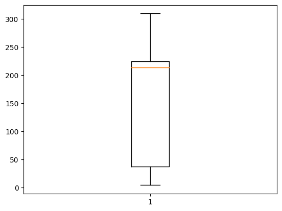

```python
plt.boxplot(data3['THIRD_VIOLATION'])
```

# Plotting

```python
data4=data3.copy()
data4
```

|  | RESTAURANT_CATEGORY | CURRENT_DEMERITS | CURRENT_GRADE | EMPLOYEE_COUNT | MEDIAN_EMPLOYEE_AGE | MEDIAN_EMPLOYEE_TENURE | INSPECTION_DEMERITS | FIRST_VIOLATION | SECOND_VIOLATION | THIRD_VIOLATION | FIRST_VIOLATION_TYPE | SECOND_VIOLATION_TYPE | THIRD_VIOLATION_TYPE | NUMBER_OF_VIOLATIONS | NEXT_INSPECTION_GRADE_C_OR_BELOW | Age_Bucket | Demerit_Bucket | INSPECTION_DEMERITS_bucket |
| --- | --- | --- | --- | --- | --- | --- | --- | --- | --- | --- | --- | --- | --- | --- | --- | --- | --- | --- |
| 0 | Food Service Establishments | 0.0 | C | 25.0 | 27.959983 | 13.004886 | 11.0 | 204.0 | 215.0 | 302.0 | Critical | Major | Critical | 4 | 0.0 | 0-30 | 0-30 | 0-30 |
| 1 | Food Service Establishments | 3.0 | A | 7.0 | 27.719365 | 3.922086 | 9.0 | 214.0 | 216.0 | 229.0 | Major | Major | Non-Major | 5 | 0.0 | 0-30 | 0-30 | 0-30 |
| 2 | Food Service Establishments | 8.0 | A | 23.0 | 26.442637 | 10.312777 | 9.0 | 202.0 | 215.0 | 233.0 | Critical | Major | Non-Major | 3 | 1.0 | 0-30 | 0-30 | 0-30 |
| 3 | Food Preparation and Cooking | 0.0 | A | 14.0 | 33.988293 | 4.163975 | 5.0 | 214.0 | 230.0 | 233.0 | Major | Non-Major | Non-Major | 3 | 0.0 | 31-40 | 0-30 | 0-30 |
| 5 | Food Service Establishments | 3.0 | A | 43.0 | 25.947206 | 3.839934 | 17.0 | 206.0 | 211.0 | 215.0 | Critical | Major | Major | 7 | 0.0 | 0-30 | 0-30 | 0-30 |
| ... | ... | ... | ... | ... | ... | ... | ... | ... | ... | ... | ... | ... | ... | ... | ... | ... | ... | ... |
| 17190 | Food Service Establishments | 9.0 | A | 9.0 | 33.383773 | 4.830165 | 4.0 | 18.0 | 28.0 | 36.0 | Non-Major | Non-Major | Non-Major | 4 | 0.0 | 31-40 | 0-30 | 0-30 |
| 17191 | Food Service Establishments | 9.0 | A | 9.0 | 33.383773 | 4.830165 | 4.0 | 18.0 | 28.0 | 36.0 | Non-Major | Non-Major | Non-Major | 4 | 0.0 | 31-40 | 0-30 | 0-30 |
| 17192 | Food Service Establishments | 9.0 | A | 9.0 | 33.383773 | 4.830165 | 4.0 | 18.0 | 28.0 | 36.0 | Non-Major | Non-Major | Non-Major | 4 | 0.0 | 31-40 | 0-30 | 0-30 |
| 17193 | Food Service Establishments | 9.0 | A | 9.0 | 33.383773 | 4.830165 | 4.0 | 18.0 | 28.0 | 36.0 | Non-Major | Non-Major | Non-Major | 4 | 0.0 | 31-40 | 0-30 | 0-30 |
| 17194 | Food Service Establishments | 9.0 | A | 9.0 | 33.383773 | 4.830165 | 4.0 | 18.0 | 28.0 | 36.0 | Non-Major | Non-Major | Non-Major | 4 | 0.0 | 31-40 | 0-30 | 0-30 |

14703 rows × 18 columns

```python
Age_wise_count=data4.groupby('Age_Bucket').count().iloc[::,:1].reset_index().copy()
Age_wise_count=Age_wise_count.rename(columns={'RESTAURANT_CATEGORY':'Count'}).copy()
Age_wise_count
```

|  | Age_Bucket | Count |
| --- | --- | --- |
| 0 | 0-30 | 8953 |
| 1 | 31-40 | 5666 |
| 2 | 41-50 | 84 |
| 3 | 51-60 | 0 |

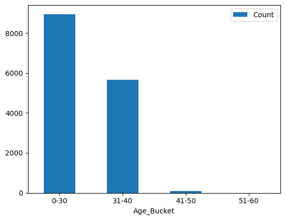

```python
Age_wise_count.plot.bar('Age_Bucket',rot=0)
```

```python
Restaurant_cate=pd.DataFrame(data4.groupby(by='RESTAURANT_CATEGORY')['EMPLOYEE_COUNT'].sum()).reset_index()
Restaurant_cate
```

|  | RESTAURANT_CATEGORY | EMPLOYEE_COUNT |
| --- | --- | --- |
| 0 | Beverage and Bar Service | 3227.0 |
| 1 | Food Preparation and Cooking | 3165.0 |
| 2 | Food Service Establishments | 205056.0 |
| 3 | Retail Food Outlets | 470.0 |

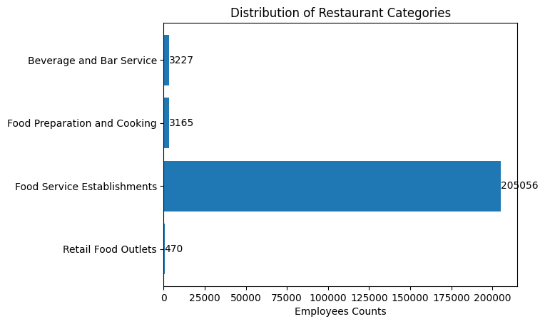

```python
bars=plt.barh(Restaurant_cate['RESTAURANT_CATEGORY'], Restaurant_cate['EMPLOYEE_COUNT'])
plt.xlabel('Employees Counts')
plt.title('Distribution of Restaurant Categories')
plt.gca().invert_yaxis()
for bar, count in zip(bars, Restaurant_cate['EMPLOYEE_COUNT']):
    plt.text(bar.get_width(), bar.get_y() + bar.get_height()/2, int(count), ha='left', va='center', fontsize=10)
plt.show()
```

```python
grade_wisecount=data4.groupby(['CURRENT_GRADE']).count().reset_index()
grade_wisecount=grade_wisecount.iloc[::,:2].copy()
grade_wisecount.rename(columns={'RESTAURANT_CATEGORY':'Count'})
```

|  | CURRENT_GRADE | Count |
| --- | --- | --- |
| 0 | A | 12937 |
| 1 | B | 208 |
| 2 | C | 1558 |

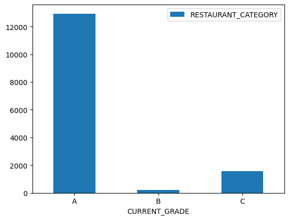

```python
grade_wisecount.plot.bar(x='CURRENT_GRADE',rot=0)
```

```python
empage_currgrad=data4.loc[::,['MEDIAN_EMPLOYEE_AGE','CURRENT_GRADE']].copy()
```

```python
empage_currgrad
```

|  | MEDIAN_EMPLOYEE_AGE | CURRENT_GRADE |
| --- | --- | --- |
| 0 | 27.959983 | C |
| 1 | 27.719365 | A |
| 2 | 26.442637 | A |
| 3 | 33.988293 | A |
| 5 | 25.947206 | A |
| ... | ... | ... |
| 17190 | 33.383773 | A |
| 17191 | 33.383773 | A |
| 17192 | 33.383773 | A |
| 17193 | 33.383773 | A |
| 17194 | 33.383773 | A |

14703 rows × 2 columns

```python
median_age_bins = [18, 30, 40, 50]
median_age_labels = ['18-30', '31-40', '41-50']
empage_currgrad['MEDIAN_EMPLOYEE_AGE_bucket'] = pd.cut(empage_currgrad['MEDIAN_EMPLOYEE_AGE'], bins=median_age_bins, labels=median_age_labels, include_lowest=True)
```

```python
empage_currgrad
```

|  | MEDIAN_EMPLOYEE_AGE | CURRENT_GRADE | MEDIAN_EMPLOYEE_AGE_bucket |
| --- | --- | --- | --- |
| 0 | 27.959983 | C | 18-30 |
| 1 | 27.719365 | A | 18-30 |
| 2 | 26.442637 | A | 18-30 |
| 3 | 33.988293 | A | 31-40 |
| 5 | 25.947206 | A | 18-30 |
| ... | ... | ... | ... |
| 17190 | 33.383773 | A | 31-40 |
| 17191 | 33.383773 | A | 31-40 |
| 17192 | 33.383773 | A | 31-40 |
| 17193 | 33.383773 | A | 31-40 |
| 17194 | 33.383773 | A | 31-40 |

14703 rows × 3 columns

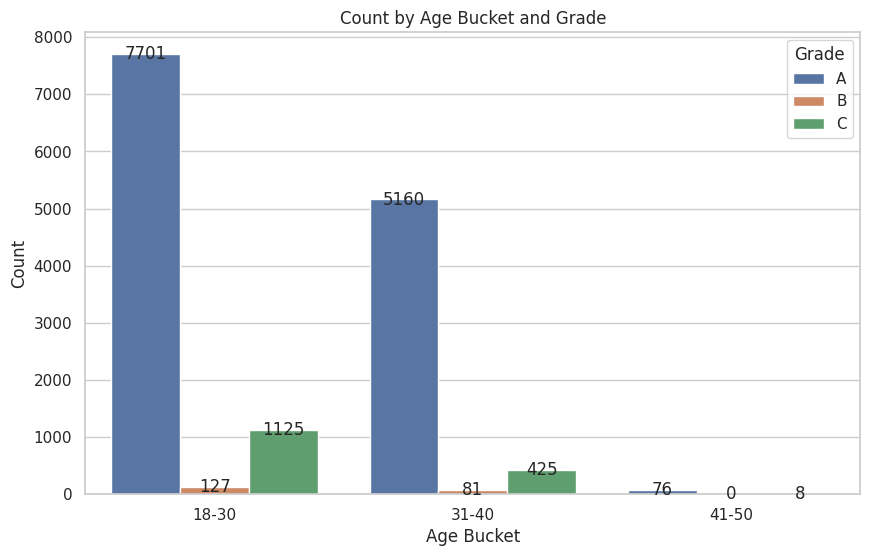

```python
grade_order = ['A', 'B', 'C']

sns.set(style="whitegrid")
plt.figure(figsize=(10, 6))

ax = sns.countplot(x="MEDIAN_EMPLOYEE_AGE_bucket", hue="CURRENT_GRADE", data=empage_currgrad, hue_order=grade_order)

for p in ax.patches:
    height = p.get_height()
    ax.annotate(f'{int(height)}', (p.get_x() + p.get_width() / 2., height), ha='center', va='center')

ax.set(xlabel="Age Bucket", ylabel="Count")
plt.title("Count by Age Bucket and Grade")
plt.legend(title="Grade", labels=grade_order)

plt.show()
```

```python
violation_cnt=data4.loc[::,['FIRST_VIOLATION_TYPE','SECOND_VIOLATION_TYPE','THIRD_VIOLATION_TYPE']]
violation_cnt
```

|  | FIRST_VIOLATION_TYPE | SECOND_VIOLATION_TYPE | THIRD_VIOLATION_TYPE |
| --- | --- | --- | --- |
| 0 | Critical | Major | Critical |
| 1 | Major | Major | Non-Major |
| 2 | Critical | Major | Non-Major |
| 3 | Major | Non-Major | Non-Major |
| 5 | Critical | Major | Major |
| ... | ... | ... | ... |
| 17190 | Non-Major | Non-Major | Non-Major |
| 17191 | Non-Major | Non-Major | Non-Major |
| 17192 | Non-Major | Non-Major | Non-Major |
| 17193 | Non-Major | Non-Major | Non-Major |
| 17194 | Non-Major | Non-Major | Non-Major |

14703 rows × 3 columns

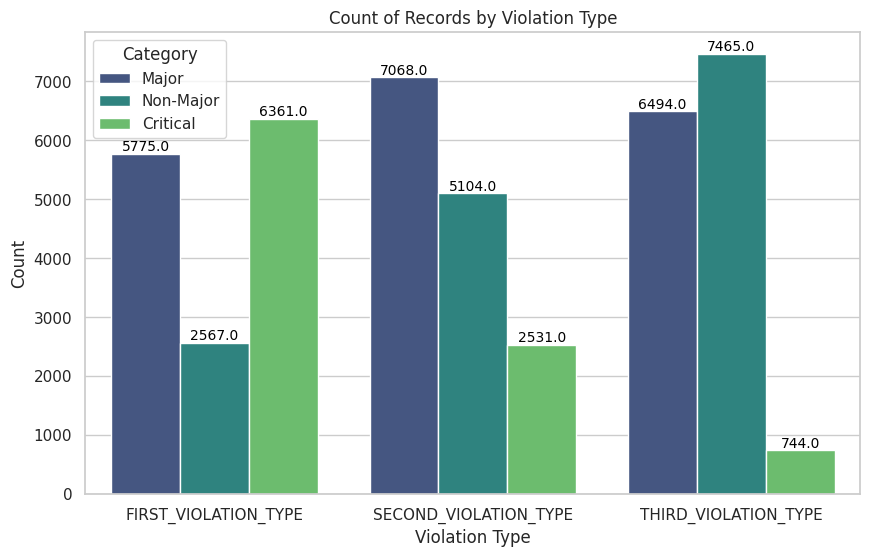

```python
category_order = ['Major', 'Non-Major', 'Critical']

plt.figure(figsize=(10, 6))
ax = sns.countplot(data=violation_cnt.melt(var_name='Violation Type', value_name='Count'), x='Violation Type', hue='Count', hue_order=category_order, palette='viridis')

ax.set(xlabel="Violation Type", ylabel="Count")
plt.title("Count of Records by Violation Type")

for p in ax.patches:
    ax.annotate(f'{p.get_height()}', (p.get_x() + p.get_width() / 2., p.get_height()),
                ha='center', va='center', fontsize=10, color='black', xytext=(0, 5),
                textcoords='offset points')

plt.legend(title="Category", labels=category_order)
plt.show()
```

# Variety of Hypothesis Tests

CURRENT_DEMERITS & CURRENT_GRADE

```python
gradewise_std=data4.loc[::,['CURRENT_DEMERITS','CURRENT_GRADE']]
gradewise_std.groupby(by='CURRENT_GRADE').std().reset_index()
```

|  | CURRENT_GRADE | CURRENT_DEMERITS |
| --- | --- | --- |
| 0 | A | 3.487419 |
| 1 | B | 5.772245 |
| 2 | C | 6.221346 |

```python
grade_A = data4[data4['CURRENT_GRADE'] == 'A']['CURRENT_DEMERITS']
grade_B = data4[data4['CURRENT_GRADE'] == 'B']['CURRENT_DEMERITS']
grade_C = data4[data4['CURRENT_GRADE'] == 'C']['CURRENT_DEMERITS']

# Kruskal-Wallis test
statistic, p_value = kruskal(grade_A,grade_B,grade_C)

# alpha
alpha = 0.05

# Compare the p-value to aplha
if p_value < alpha:
    print("Reject the null hypothesis: 'CURRENT_GRADE' has a significant effect on 'CURRENT_DEMERITS.'")
else:
    print("Fail to reject the null hypothesis: 'CURRENT_GRADE' does not have a significant effect on 'CURRENT_DEMERITS.'")
```

```
Reject the null hypothesis: 'CURRENT_GRADE' has a significant effect on 'CURRENT_DEMERITS.'
```

Does Median Employee Age affects the current *grade*?

```python
grade_A = data4[data4['CURRENT_GRADE'] == 'A']['MEDIAN_EMPLOYEE_AGE']
grade_B = data4[data4['CURRENT_GRADE'] == 'B']['MEDIAN_EMPLOYEE_AGE']
grade_C = data4[data4['CURRENT_GRADE'] == 'C']['MEDIAN_EMPLOYEE_AGE']


statistic, p_value = kruskal(grade_A, grade_B, grade_C)
print("p-value:", p_value)
alpha = 0.05

if p_value < alpha:
    print("Reject the null hypothesis: 'CURRENT_GRADE' has a significant effect on 'MEDIAN_EMPLOYEE_AGE.'")
else:
    print("Fail to reject the null hypothesis: 'CURRENT_GRADE' does not have a significant effect on 'MEDIAN_EMPLOYEE_AGE.'")
```

```
p-value: 6.8035365840117915e-15
Reject the null hypothesis: 'CURRENT_GRADE' has a significant effect on 'MEDIAN_EMPLOYEE_AGE.'
```

Do Current Grades affects the Next Inspaection Garde C or Below?

```python
group_A = data4[data4['CURRENT_GRADE'] == 'A']['NEXT_INSPECTION_GRADE_C_OR_BELOW']
group_B = data4[data4['CURRENT_GRADE'] == 'B']['NEXT_INSPECTION_GRADE_C_OR_BELOW']
group_C = data4[data4['CURRENT_GRADE'] == 'C']['NEXT_INSPECTION_GRADE_C_OR_BELOW']

statistic, p_value = kruskal(group_A, group_B, group_C)

print("p-value:", p_value)

alpha = 0.05
if p_value < alpha:
    print("Reject the null hypothesis: 'CURRENT_GRADE' has a significant effect on 'NEXT_INSPECTION_GRADE_C_OR_BELOW.'")
else:
    print("Fail to reject the null hypothesis: 'CURRENT_GRADE' does not have a significant effect on 'NEXT_INSPECTION_GRADE_C_OR_BELOW.'")
```

```
p-value: 1.7902579415856482e-49
Reject the null hypothesis: 'CURRENT_GRADE' has a significant effect on 'NEXT_INSPECTION_GRADE_C_OR_BELOW.'
```

Do Current Demerit affects the NEXT_INSPECTION_GRADE_C_OR_BEL?

```python
group_0 = data4[data4['NEXT_INSPECTION_GRADE_C_OR_BELOW'] == 0.0]['CURRENT_DEMERITS']
group_1 = data4[data4['NEXT_INSPECTION_GRADE_C_OR_BELOW'] == 1.0]['CURRENT_DEMERITS']

statistic, p_value = kruskal(group_0, group_1)

print("p-value:", p_value)


alpha = 0.05
if p_value < alpha:
    print("Reject the null hypothesis: 'NEXT_INSPECTION_GRADE_C_OR_BELOW' has a significant effect on 'CURRENT_DEMERITS.'")
else:
    print("Fail to reject the null hypothesis: 'NEXT_INSPECTION_GRADE_C_OR_BELOW' does not have a significant effect on 'CURRENT_DEMERITS.'")
```

```
p-value: 2.0994320434286004e-13
Reject the null hypothesis: 'NEXT_INSPECTION_GRADE_C_OR_BELOW' has a significant effect on 'CURRENT_DEMERITS.'
```

Does INSPECTION_DEMERITS effects the NEXT_INSPECTION_GRADE_C_OR_BELOW ?

```python
group_0 = data4[data4['NEXT_INSPECTION_GRADE_C_OR_BELOW'] == 0.0]['INSPECTION_DEMERITS']
group_1 = data4[data4['NEXT_INSPECTION_GRADE_C_OR_BELOW'] == 1.0]['INSPECTION_DEMERITS']

statistic, p_value = kruskal(group_0, group_1)
print("p-value:", p_value)

alpha = 0.05
if p_value < alpha:
     print("Reject the null hypothesis: 'NEXT_INSPECTION_GRADE_C_OR_BELOW' has a significant effect on 'INSPECTION_DEMERITS.'")
else:
    print("Fail to reject the null hypothesis: 'NEXT_INSPECTION_GRADE_C_OR_BELOW' does not have a significant effect on 'INSPECTION_DEMERITS.'")
```

```
p-value: 6.139448047888555e-29
Reject the null hypothesis: 'NEXT_INSPECTION_GRADE_C_OR_BELOW' has a significant effect on 'INSPECTION_DEMERITS.'
```

Does Resturant Categorues have effect on Next Inspection Grade C or Below?

```python
group_Food_Service_Establishments = data4[data4['RESTAURANT_CATEGORY'] == 'Food Service Establishments']['NEXT_INSPECTION_GRADE_C_OR_BELOW']
group_Food_Preparation_and_Cooking = data4[data4['RESTAURANT_CATEGORY'] == 'Food Preparation and Cooking']['NEXT_INSPECTION_GRADE_C_OR_BELOW']
group_Beverage_and_Bar_Service = data4[data4['RESTAURANT_CATEGORY'] == 'Beverage and Bar Service']['NEXT_INSPECTION_GRADE_C_OR_BELOW']
group_Retail_Food_Outlets = data4[data4['RESTAURANT_CATEGORY'] == 'Retail Food Outlets']['NEXT_INSPECTION_GRADE_C_OR_BELOW']

statistic, p_value = kruskal(group_Food_Service_Establishments, group_Food_Preparation_and_Cooking,group_Beverage_and_Bar_Service,group_Retail_Food_Outlets)
print("p-value:", p_value)

alpha = 0.05
if p_value < alpha:
     print("Reject the null hypothesis: 'RESTAURANT_CATEGORY' has a significant effect on 'NEXT_INSPECTION_GRADE_C_OR_BELOW.'")
else:
    print("Fail to reject the null hypothesis: 'RESTAURANT_CATEGORY' does not have a significant effect on 'NEXT_INSPECTION_GRADE_C_OR_BELOW.'")
```

```
p-value: 0.016814359852995942
Reject the null hypothesis: 'RESTAURANT_CATEGORY' has a significant effect on 'NEXT_INSPECTION_GRADE_C_OR_BELOW.'
```

```python
data4.corr()
```

|  | CURRENT_DEMERITS | EMPLOYEE_COUNT | MEDIAN_EMPLOYEE_AGE | MEDIAN_EMPLOYEE_TENURE | INSPECTION_DEMERITS | FIRST_VIOLATION | SECOND_VIOLATION | THIRD_VIOLATION | NUMBER_OF_VIOLATIONS | NEXT_INSPECTION_GRADE_C_OR_BELOW |
| --- | --- | --- | --- | --- | --- | --- | --- | --- | --- | --- |
| CURRENT_DEMERITS | 1.000000 | -0.049201 | 0.090129 | 0.046333 | -0.006086 | 0.001301 | -0.121442 | -0.126677 | 0.049311 | -0.035874 |
| EMPLOYEE_COUNT | -0.049201 | 1.000000 | -0.048868 | -0.050797 | 0.073353 | -0.002171 | 0.087325 | 0.089162 | 0.048049 | 0.033522 |
| MEDIAN_EMPLOYEE_AGE | 0.090129 | -0.048868 | 1.000000 | 0.017704 | -0.098943 | 0.002257 | -0.137899 | -0.141552 | -0.049270 | -0.045843 |
| MEDIAN_EMPLOYEE_TENURE | 0.046333 | -0.050797 | 0.017704 | 1.000000 | -0.027017 | -0.007315 | -0.015275 | -0.018007 | -0.025286 | -0.029237 |
| INSPECTION_DEMERITS | -0.006086 | 0.073353 | -0.098943 | -0.027017 | 1.000000 | -0.002348 | 0.289613 | 0.270335 | 0.871796 | 0.094899 |
| FIRST_VIOLATION | 0.001301 | -0.002171 | 0.002257 | -0.007315 | -0.002348 | 1.000000 | -0.012897 | -0.012948 | -0.001344 | -0.003415 |
| SECOND_VIOLATION | -0.121442 | 0.087325 | -0.137899 | -0.015275 | 0.289613 | -0.012897 | 1.000000 | 0.989886 | 0.208731 | 0.061249 |
| THIRD_VIOLATION | -0.126677 | 0.089162 | -0.141552 | -0.018007 | 0.270335 | -0.012948 | 0.989886 | 1.000000 | 0.179011 | 0.060148 |
| NUMBER_OF_VIOLATIONS | 0.049311 | 0.048049 | -0.049270 | -0.025286 | 0.871796 | -0.001344 | 0.208731 | 0.179011 | 1.000000 | 0.079143 |
| NEXT_INSPECTION_GRADE_C_OR_BELOW | -0.035874 | 0.033522 | -0.045843 | -0.029237 | 0.094899 | -0.003415 | 0.061249 | 0.060148 | 0.079143 | 1.000000 |

You can drop either SECOND_VIOLATION or THIRD_VIOLATION as they are having strong correlation.

```python
cols=['RESTAURANT_CATEGORY','CURRENT_DEMERITS','CURRENT_GRADE','EMPLOYEE_COUNT','MEDIAN_EMPLOYEE_AGE',
      'MEDIAN_EMPLOYEE_TENURE','INSPECTION_DEMERITS','FIRST_VIOLATION',
      'SECOND_VIOLATION','THIRD_VIOLATION','NUMBER_OF_VIOLATIONS','NEXT_INSPECTION_GRADE_C_OR_BELOW']
data5=data4.loc[::,cols].copy()
data5
```

|  | RESTAURANT_CATEGORY | CURRENT_DEMERITS | CURRENT_GRADE | EMPLOYEE_COUNT | MEDIAN_EMPLOYEE_AGE | MEDIAN_EMPLOYEE_TENURE | INSPECTION_DEMERITS | FIRST_VIOLATION | SECOND_VIOLATION | THIRD_VIOLATION | NUMBER_OF_VIOLATIONS | NEXT_INSPECTION_GRADE_C_OR_BELOW |
| --- | --- | --- | --- | --- | --- | --- | --- | --- | --- | --- | --- | --- |
| 0 | Food Service Establishments | 0.0 | C | 25.0 | 27.959983 | 13.004886 | 11.0 | 204.0 | 215.0 | 302.0 | 4 | 0.0 |
| 1 | Food Service Establishments | 3.0 | A | 7.0 | 27.719365 | 3.922086 | 9.0 | 214.0 | 216.0 | 229.0 | 5 | 0.0 |
| 2 | Food Service Establishments | 8.0 | A | 23.0 | 26.442637 | 10.312777 | 9.0 | 202.0 | 215.0 | 233.0 | 3 | 1.0 |
| 3 | Food Preparation and Cooking | 0.0 | A | 14.0 | 33.988293 | 4.163975 | 5.0 | 214.0 | 230.0 | 233.0 | 3 | 0.0 |
| 5 | Food Service Establishments | 3.0 | A | 43.0 | 25.947206 | 3.839934 | 17.0 | 206.0 | 211.0 | 215.0 | 7 | 0.0 |
| ... | ... | ... | ... | ... | ... | ... | ... | ... | ... | ... | ... | ... |
| 17190 | Food Service Establishments | 9.0 | A | 9.0 | 33.383773 | 4.830165 | 4.0 | 18.0 | 28.0 | 36.0 | 4 | 0.0 |
| 17191 | Food Service Establishments | 9.0 | A | 9.0 | 33.383773 | 4.830165 | 4.0 | 18.0 | 28.0 | 36.0 | 4 | 0.0 |
| 17192 | Food Service Establishments | 9.0 | A | 9.0 | 33.383773 | 4.830165 | 4.0 | 18.0 | 28.0 | 36.0 | 4 | 0.0 |
| 17193 | Food Service Establishments | 9.0 | A | 9.0 | 33.383773 | 4.830165 | 4.0 | 18.0 | 28.0 | 36.0 | 4 | 0.0 |
| 17194 | Food Service Establishments | 9.0 | A | 9.0 | 33.383773 | 4.830165 | 4.0 | 18.0 | 28.0 | 36.0 | 4 | 0.0 |

14703 rows × 12 columns

```python
data5.var(numeric_only=True)
```

```
CURRENT_DEMERITS                    1.679807e+01
EMPLOYEE_COUNT                      7.624208e+01
MEDIAN_EMPLOYEE_AGE                 2.370278e+01
MEDIAN_EMPLOYEE_TENURE              4.054990e+00
INSPECTION_DEMERITS                 6.661818e+01
FIRST_VIOLATION                     5.118576e+09
SECOND_VIOLATION                    7.367225e+03
THIRD_VIOLATION                     6.966239e+03
NUMBER_OF_VIOLATIONS                7.845921e+00
NEXT_INSPECTION_GRADE_C_OR_BELOW    1.288642e-01
dtype: float64
```

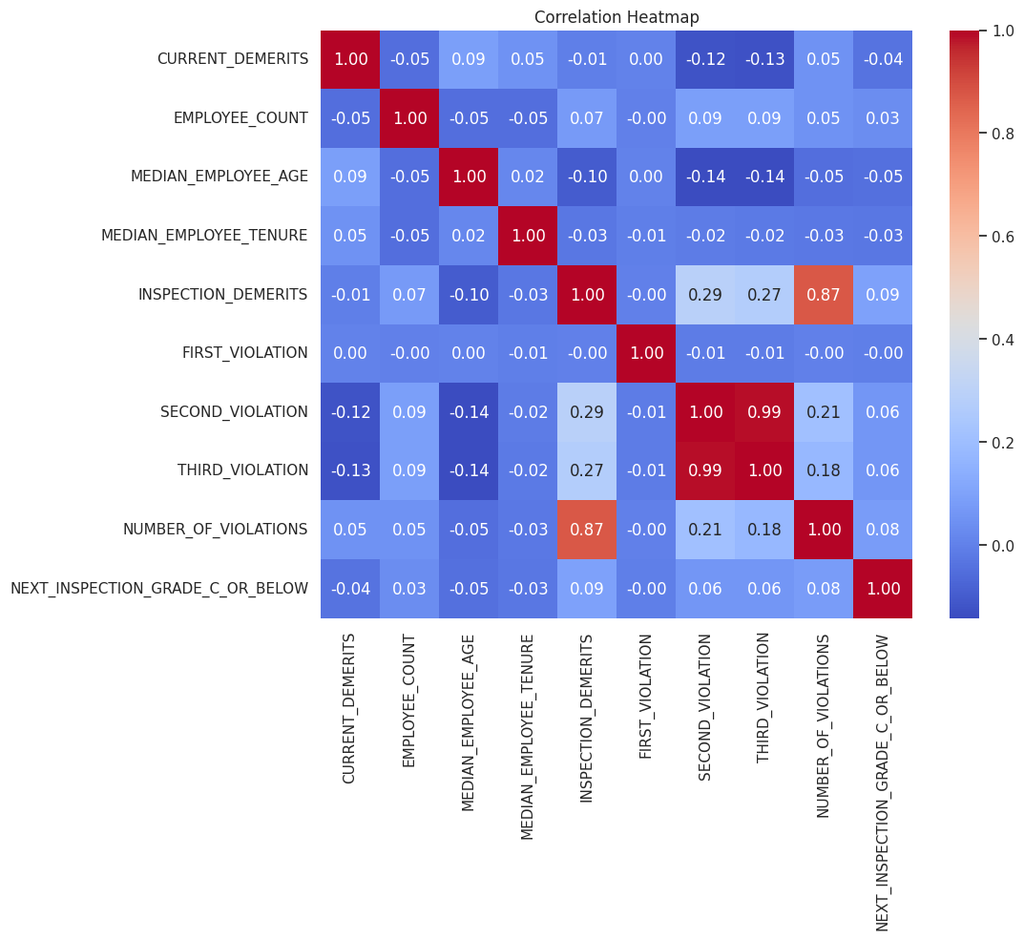

```python
correlation_matrix = data5.corr()
plt.figure(figsize=(10, 8))
sns.heatmap(correlation_matrix, annot=True, cmap="coolwarm", fmt=".2f")
plt.title("Correlation Heatmap")
plt.show()
```

```python
data6=data5.drop(columns=['THIRD_VIOLATION','INSPECTION_DEMERITS']).copy()
data6
```

|  | RESTAURANT_CATEGORY | CURRENT_DEMERITS | CURRENT_GRADE | EMPLOYEE_COUNT | MEDIAN_EMPLOYEE_AGE | MEDIAN_EMPLOYEE_TENURE | FIRST_VIOLATION | SECOND_VIOLATION | NUMBER_OF_VIOLATIONS | NEXT_INSPECTION_GRADE_C_OR_BELOW |
| --- | --- | --- | --- | --- | --- | --- | --- | --- | --- | --- |
| 0 | Food Service Establishments | 0.0 | C | 25.0 | 27.959983 | 13.004886 | 204.0 | 215.0 | 4 | 0.0 |
| 1 | Food Service Establishments | 3.0 | A | 7.0 | 27.719365 | 3.922086 | 214.0 | 216.0 | 5 | 0.0 |
| 2 | Food Service Establishments | 8.0 | A | 23.0 | 26.442637 | 10.312777 | 202.0 | 215.0 | 3 | 1.0 |
| 3 | Food Preparation and Cooking | 0.0 | A | 14.0 | 33.988293 | 4.163975 | 214.0 | 230.0 | 3 | 0.0 |
| 5 | Food Service Establishments | 3.0 | A | 43.0 | 25.947206 | 3.839934 | 206.0 | 211.0 | 7 | 0.0 |
| ... | ... | ... | ... | ... | ... | ... | ... | ... | ... | ... |
| 17190 | Food Service Establishments | 9.0 | A | 9.0 | 33.383773 | 4.830165 | 18.0 | 28.0 | 4 | 0.0 |
| 17191 | Food Service Establishments | 9.0 | A | 9.0 | 33.383773 | 4.830165 | 18.0 | 28.0 | 4 | 0.0 |
| 17192 | Food Service Establishments | 9.0 | A | 9.0 | 33.383773 | 4.830165 | 18.0 | 28.0 | 4 | 0.0 |
| 17193 | Food Service Establishments | 9.0 | A | 9.0 | 33.383773 | 4.830165 | 18.0 | 28.0 | 4 | 0.0 |
| 17194 | Food Service Establishments | 9.0 | A | 9.0 | 33.383773 | 4.830165 | 18.0 | 28.0 | 4 | 0.0 |

14703 rows × 10 columns

Dataset is Imbalanced

```python
score_0=data6[data6['NEXT_INSPECTION_GRADE_C_OR_BELOW']==0]
score_1=data6[data6['NEXT_INSPECTION_GRADE_C_OR_BELOW']==1]
```

```python
print(score_0.shape,score_1.shape)
```

```
(12469, 10) (2234, 10)
```

```python
from sklearn.preprocessing import LabelEncoder
from sklearn.model_selection import train_test_split
from sklearn.pipeline import Pipeline
```

```python
one_hot = pd.get_dummies(data6['RESTAURANT_CATEGORY'], prefix='Resturant')
grade_mapping = {'A': 2, 'B': 1, 'C': 0}
data6 = pd.concat([data6, one_hot], axis=1)
data6['CURRENT_GRADE'] = data6['CURRENT_GRADE'].map(grade_mapping)
label_encoder = LabelEncoder()
data6['CURRENT_GRADE'] = label_encoder.fit_transform(data6['CURRENT_GRADE'])

data6
```

|  | RESTAURANT_CATEGORY | CURRENT_DEMERITS | CURRENT_GRADE | EMPLOYEE_COUNT | MEDIAN_EMPLOYEE_AGE | MEDIAN_EMPLOYEE_TENURE | FIRST_VIOLATION | SECOND_VIOLATION | NUMBER_OF_VIOLATIONS | NEXT_INSPECTION_GRADE_C_OR_BELOW | Resturant_Beverage and Bar Service | Resturant_Food Preparation and Cooking | Resturant_Food Service Establishments | Resturant_Retail Food Outlets |
| --- | --- | --- | --- | --- | --- | --- | --- | --- | --- | --- | --- | --- | --- | --- |
| 0 | Food Service Establishments | 0.0 | 0 | 25.0 | 27.959983 | 13.004886 | 204.0 | 215.0 | 4 | 0.0 | 0 | 0 | 1 | 0 |
| 1 | Food Service Establishments | 3.0 | 2 | 7.0 | 27.719365 | 3.922086 | 214.0 | 216.0 | 5 | 0.0 | 0 | 0 | 1 | 0 |
| 2 | Food Service Establishments | 8.0 | 2 | 23.0 | 26.442637 | 10.312777 | 202.0 | 215.0 | 3 | 1.0 | 0 | 0 | 1 | 0 |
| 3 | Food Preparation and Cooking | 0.0 | 2 | 14.0 | 33.988293 | 4.163975 | 214.0 | 230.0 | 3 | 0.0 | 0 | 1 | 0 | 0 |
| 5 | Food Service Establishments | 3.0 | 2 | 43.0 | 25.947206 | 3.839934 | 206.0 | 211.0 | 7 | 0.0 | 0 | 0 | 1 | 0 |
| ... | ... | ... | ... | ... | ... | ... | ... | ... | ... | ... | ... | ... | ... | ... |
| 17190 | Food Service Establishments | 9.0 | 2 | 9.0 | 33.383773 | 4.830165 | 18.0 | 28.0 | 4 | 0.0 | 0 | 0 | 1 | 0 |
| 17191 | Food Service Establishments | 9.0 | 2 | 9.0 | 33.383773 | 4.830165 | 18.0 | 28.0 | 4 | 0.0 | 0 | 0 | 1 | 0 |
| 17192 | Food Service Establishments | 9.0 | 2 | 9.0 | 33.383773 | 4.830165 | 18.0 | 28.0 | 4 | 0.0 | 0 | 0 | 1 | 0 |
| 17193 | Food Service Establishments | 9.0 | 2 | 9.0 | 33.383773 | 4.830165 | 18.0 | 28.0 | 4 | 0.0 | 0 | 0 | 1 | 0 |
| 17194 | Food Service Establishments | 9.0 | 2 | 9.0 | 33.383773 | 4.830165 | 18.0 | 28.0 | 4 | 0.0 | 0 | 0 | 1 | 0 |

14703 rows × 14 columns

```python
cols1=['Resturant_Beverage and Bar Service','Resturant_Food Preparation and Cooking','Resturant_Food Service Establishments','Resturant_Retail Food Outlets',
      'CURRENT_DEMERITS', 'CURRENT_GRADE','EMPLOYEE_COUNT', 'MEDIAN_EMPLOYEE_AGE', 'MEDIAN_EMPLOYEE_TENURE', 'FIRST_VIOLATION', 'SECOND_VIOLATION',
       'NUMBER_OF_VIOLATIONS', 'NEXT_INSPECTION_GRADE_C_OR_BELOW']
```

```python
data6=data6.loc[::,cols1].copy()
data6
```

|  | Resturant_Beverage and Bar Service | Resturant_Food Preparation and Cooking | Resturant_Food Service Establishments | Resturant_Retail Food Outlets | CURRENT_DEMERITS | CURRENT_GRADE | EMPLOYEE_COUNT | MEDIAN_EMPLOYEE_AGE | MEDIAN_EMPLOYEE_TENURE | FIRST_VIOLATION | SECOND_VIOLATION | NUMBER_OF_VIOLATIONS | NEXT_INSPECTION_GRADE_C_OR_BELOW |
| --- | --- | --- | --- | --- | --- | --- | --- | --- | --- | --- | --- | --- | --- |
| 0 | 0 | 0 | 1 | 0 | 0.0 | 0 | 25.0 | 27.959983 | 13.004886 | 204.0 | 215.0 | 4 | 0.0 |
| 1 | 0 | 0 | 1 | 0 | 3.0 | 2 | 7.0 | 27.719365 | 3.922086 | 214.0 | 216.0 | 5 | 0.0 |
| 2 | 0 | 0 | 1 | 0 | 8.0 | 2 | 23.0 | 26.442637 | 10.312777 | 202.0 | 215.0 | 3 | 1.0 |
| 3 | 0 | 1 | 0 | 0 | 0.0 | 2 | 14.0 | 33.988293 | 4.163975 | 214.0 | 230.0 | 3 | 0.0 |
| 5 | 0 | 0 | 1 | 0 | 3.0 | 2 | 43.0 | 25.947206 | 3.839934 | 206.0 | 211.0 | 7 | 0.0 |
| ... | ... | ... | ... | ... | ... | ... | ... | ... | ... | ... | ... | ... | ... |
| 17190 | 0 | 0 | 1 | 0 | 9.0 | 2 | 9.0 | 33.383773 | 4.830165 | 18.0 | 28.0 | 4 | 0.0 |
| 17191 | 0 | 0 | 1 | 0 | 9.0 | 2 | 9.0 | 33.383773 | 4.830165 | 18.0 | 28.0 | 4 | 0.0 |
| 17192 | 0 | 0 | 1 | 0 | 9.0 | 2 | 9.0 | 33.383773 | 4.830165 | 18.0 | 28.0 | 4 | 0.0 |
| 17193 | 0 | 0 | 1 | 0 | 9.0 | 2 | 9.0 | 33.383773 | 4.830165 | 18.0 | 28.0 | 4 | 0.0 |
| 17194 | 0 | 0 | 1 | 0 | 9.0 | 2 | 9.0 | 33.383773 | 4.830165 | 18.0 | 28.0 | 4 | 0.0 |

14703 rows × 13 columns

```python
data6.to_csv('/content/drive/MyDrive/Nationwide/data6.csv')
```

```python
data6=pd.read_csv('/content/drive/MyDrive/Nationwide/data6.csv').iloc[::,1:]
data6
```

|  | Resturant_Beverage and Bar Service | Resturant_Food Preparation and Cooking | Resturant_Food Service Establishments | Resturant_Retail Food Outlets | CURRENT_DEMERITS | CURRENT_GRADE | EMPLOYEE_COUNT | MEDIAN_EMPLOYEE_AGE | MEDIAN_EMPLOYEE_TENURE | FIRST_VIOLATION | SECOND_VIOLATION | NUMBER_OF_VIOLATIONS | NEXT_INSPECTION_GRADE_C_OR_BELOW |
| --- | --- | --- | --- | --- | --- | --- | --- | --- | --- | --- | --- | --- | --- |
| 0 | 0 | 0 | 1 | 0 | 0.0 | 0 | 25.0 | 27.959983 | 13.004886 | 204.0 | 215.0 | 4 | 0.0 |
| 1 | 0 | 0 | 1 | 0 | 3.0 | 2 | 7.0 | 27.719365 | 3.922086 | 214.0 | 216.0 | 5 | 0.0 |
| 2 | 0 | 0 | 1 | 0 | 8.0 | 2 | 23.0 | 26.442637 | 10.312777 | 202.0 | 215.0 | 3 | 1.0 |
| 3 | 0 | 1 | 0 | 0 | 0.0 | 2 | 14.0 | 33.988293 | 4.163975 | 214.0 | 230.0 | 3 | 0.0 |
| 4 | 0 | 0 | 1 | 0 | 3.0 | 2 | 43.0 | 25.947206 | 3.839934 | 206.0 | 211.0 | 7 | 0.0 |
| ... | ... | ... | ... | ... | ... | ... | ... | ... | ... | ... | ... | ... | ... |
| 14698 | 0 | 0 | 1 | 0 | 9.0 | 2 | 9.0 | 33.383773 | 4.830165 | 18.0 | 28.0 | 4 | 0.0 |
| 14699 | 0 | 0 | 1 | 0 | 9.0 | 2 | 9.0 | 33.383773 | 4.830165 | 18.0 | 28.0 | 4 | 0.0 |
| 14700 | 0 | 0 | 1 | 0 | 9.0 | 2 | 9.0 | 33.383773 | 4.830165 | 18.0 | 28.0 | 4 | 0.0 |
| 14701 | 0 | 0 | 1 | 0 | 9.0 | 2 | 9.0 | 33.383773 | 4.830165 | 18.0 | 28.0 | 4 | 0.0 |
| 14702 | 0 | 0 | 1 | 0 | 9.0 | 2 | 9.0 | 33.383773 | 4.830165 | 18.0 | 28.0 | 4 | 0.0 |

14703 rows × 13 columns

```python
data6.dtypes
```

```
Resturant_Beverage and Bar Service          int64
Resturant_Food Preparation and Cooking      int64
Resturant_Food Service Establishments       int64
Resturant_Retail Food Outlets               int64
CURRENT_DEMERITS                          float64
CURRENT_GRADE                               int64
EMPLOYEE_COUNT                            float64
MEDIAN_EMPLOYEE_AGE                       float64
MEDIAN_EMPLOYEE_TENURE                    float64
FIRST_VIOLATION                           float64
SECOND_VIOLATION                          float64
NUMBER_OF_VIOLATIONS                        int64
NEXT_INSPECTION_GRADE_C_OR_BELOW          float64
dtype: object
```

Dataset is Imbalance

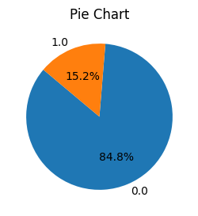

```python
data = data6['NEXT_INSPECTION_GRADE_C_OR_BELOW'].value_counts()

plt.figure(figsize=(3, 3))
plt.pie(data, labels=data.index, autopct='%1.1f%%', startangle=140)
plt.title('Pie Chart')
plt.show()
```

```python
X=data6.iloc[::,:-1]
Y=data6.iloc[::,-1]
```

```python
smk = SMOTETomek(random_state=42)
X_res,y_res=smk.fit_resample(X,Y)
```

```python
X_res.shape,y_res.shape
```

```
((24646, 12), (24646,))
```

```python
print('Original dataset shape {}'.format(Counter(Y)))
print('Resampled dataset shape {}'.format(Counter(y_res)))
```

```
Original dataset shape Counter({0.0: 12469, 1.0: 2234})
Resampled dataset shape Counter({0.0: 12323, 1.0: 12323})
```

```python
X_train, X_test, y_train, y_test = train_test_split(X_res, y_res, test_size=0.2, random_state=4, stratify=y_res)
```

```python
y_train.value_counts()
```

```
1.0    9858
0.0    9858
Name: NEXT_INSPECTION_GRADE_C_OR_BELOW, dtype: int64
```

```python
param_grid_cat = {
    'iterations': [500, 1000],
    'depth': [6, 8, 10],
    'learning_rate': [0.05, 0.1, 0.15],
    'auto_class_weights': [None, 'Balanced']
}
```

```python
catboost = CatBoostClassifier(cat_features=[0,1,2,3])

grid_search = GridSearchCV(estimator=catboost, param_grid=param_grid_cat, cv=3, scoring='f1', n_jobs=-1)

grid_search.fit(X_train, y_train)

print("Best Parameters: ", grid_search.best_params_)
print("Best F1 Score: ", grid_search.best_score_)

best_catboost_model = grid_search.best_estimator_
```

[output not shown]

[output cut: 447 more lines]

```
487:	learn: 0.1064283	total: 21.7s	remaining: 533ms
488:	learn: 0.1062917	total: 21.7s	remaining: 489ms
489:	learn: 0.1061125	total: 21.8s	remaining: 444ms
490:	learn: 0.1060050	total: 21.8s	remaining: 400ms
491:	learn: 0.1058727	total: 21.9s	remaining: 355ms
492:	learn: 0.1056945	total: 21.9s	remaining: 311ms
493:	learn: 0.1055341	total: 21.9s	remaining: 266ms
494:	learn: 0.1053257	total: 22s	remaining: 222ms
495:	learn: 0.1050799	total: 22s	remaining: 178ms
496:	learn: 0.1048063	total: 22.1s	remaining: 133ms
497:	learn: 0.1045669	total: 22.1s	remaining: 88.7ms
498:	learn: 0.1042934	total: 22.1s	remaining: 44.3ms
499:	learn: 0.1040779	total: 22.2s	remaining: 0us
Best Parameters:  {'auto_class_weights': 'Balanced', 'depth': 10, 'iterations': 500, 'learning_rate': 0.1}
Best F1 Score:  0.8872153048855411
```

```python
y_pred = best_catboost_model.predict(X_test)
```

```python
accuracy = accuracy_score(y_test, y_pred)
print("Accuracy:", accuracy)
print(classification_report(y_test, y_pred))
```

```
Accuracy: 0.9085192697768762
              precision    recall  f1-score   support

         0.0       0.87      0.96      0.91      2465
         1.0       0.96      0.86      0.90      2465

    accuracy                           0.91      4930
   macro avg       0.91      0.91      0.91      4930
weighted avg       0.91      0.91      0.91      4930
```

```python
f1_score(y_pred,y_test)
```

```
0.9034467994005565
```

```python
feature_importance = best_catboost_model.get_feature_importance()
importance_df = pd.DataFrame({'Feature': X_train.columns, 'Importance': feature_importance})
importance_df = importance_df.sort_values(by='Importance', ascending=False)
```

```python
importance_df
```

|  | Feature | Importance |
| --- | --- | --- |
| 4 | CURRENT_DEMERITS | 26.827451 |
| 6 | EMPLOYEE_COUNT | 22.238176 |
| 10 | SECOND_VIOLATION | 15.172376 |
| 9 | FIRST_VIOLATION | 11.827328 |
| 7 | MEDIAN_EMPLOYEE_AGE | 7.105705 |
| 8 | MEDIAN_EMPLOYEE_TENURE | 6.257057 |
| 11 | NUMBER_OF_VIOLATIONS | 4.407167 |
| 5 | CURRENT_GRADE | 4.211271 |
| 2 | Resturant_Food Service Establishments | 1.069582 |
| 1 | Resturant_Food Preparation and Cooking | 0.478940 |
| 0 | Resturant_Beverage and Bar Service | 0.383409 |
| 3 | Resturant_Retail Food Outlets | 0.021539 |